# 🧬 Predicting Heart Disease ❤️

# 📂 Overview

**Background**

The **Heart Disease Prediction** dataset is derived from clinical and diagnostic attributes commonly used in cardiology to assess the risk of cardiovascular diseases. The dataset is based on real-world medical examinations, including **demographic information, physiological measurements, electrocardiographic results, and imaging-based indicators**.

It combines both **numerical and categorical** variables reflecting patients’ physical condition, blood chemistry, heart electrical activity, and coronary artery status. These features are widely applied in medical research and machine learning studies for early detection and risk stratification of heart diseases.

The dataset is well-suited for:

- **Exploratory Data Analysis (EDA) on cardiovascular risk factors**
- **Feature engineering and medical risk scoring**
- **Binary classification modeling**
- **Performance benchmarking of ML algorithms on clinical datasets**

**Goal of the Project**

Build a machine learning model to **predict the presence of heart disease** (`Heart Disease`: Presence/Absence) based on patients’ clinical, laboratory, and diagnostic indicators.

**Key Features**

| Feature Name | Description |
| --- | --- |
| `id` | Unique patient identifier, not used for modeling |
| `Age` | Age of the patient (years) |
| `Sex` | Gender (1 = male, 0 = female) |
| `Chest pain type` | Type of chest pain experienced |
| `BP` | Resting blood pressure (mmHg) |
| `Cholesterol` | Serum cholesterol level (mg/dl) |
| `FBS over 120` | Fasting blood sugar > 120 mg/dl (1 = true, 0 = false) |
| `EKG results` | Resting electrocardiographic results |
| `Max HR` | Maximum heart rate achieved |
| `Exercise angina` | Exercise-induced angina (1 = yes, 0 = no) |
| `ST depression` | ST segment depression induced by exercise (oldpeak) |
| `Slope of ST` | Slope of the peak exercise ST segment |
| `Number of vessels fluro` | Number of major vessels colored by fluoroscopy (0–3) |
| `Thallium` | Thallium stress test result |
| `Heart Disease` | Target variable (Presence = disease, Absence = no disease) |

**Files Provided**

From a standard **Heart Disease clinical dataset (UCI-style / Kaggle distribution)**:

- `train.csv`: Training dataset containing the target variable.
- `test.csv`: Test dataset without target.
- `sample_submission.csv`: Submission format template (if applicable).
- The dataset is curated from real clinical measurements and widely used in academic research and ML benchmarking.

(Source: [Kaggle Competition – S6E2](https://www.kaggle.com/competitions/playground-series-s6e2))

(Source: [Heart Disease Original](https://www.kaggle.com/datasets/neurocipher/heartdisease))

# Import Libraries

# Import Libraries

```python
!pip install statsmodels > pip_log_statsmodels.txt 2>&1
!pip install scikit_posthocs > pip_log_scikit_posthocs.txt 2>&1
!pip install pingouin > pip_log_pingouin.txt 2>&1
```

```python
# =====================================================
# Core Data Manipulation
# =====================================================
import pandas as pd                                         # DataFrame creation & manipulation
import numpy as np                                          # Numerical computing (arrays, math ops)

# =====================================================
# Visualization & Interactive Plotting
# =====================================================
import matplotlib.pyplot as plt                             # Base plotting (static matplotlib)
import seaborn as sns                                       # Statistical & high-level visualization

# =====================================================
# Statistical Distribution & Diagnostics
# =====================================================
from scipy.stats import (
    skew,                                                   # Distribution skewness
    kurtosis,                                               # Distribution kurtosis
    probplot                                                # Q-Q plot for normality check
)

# =====================================================
# Jupyter Display Utilities
# =====================================================
from IPython.display import (
    display,                                                # Display DataFrame/objects
    HTML                                                    # Render custom HTML in notebook
)

# =====================================================
# Machine Learning - Data Splitting & Preprocessing
# =====================================================
from sklearn.model_selection import (
    StratifiedKFold                                         # Stratified cross-validation
)
from sklearn.base import (
    BaseEstimator,                                          # Base class for custom estimators
    TransformerMixin                                        # Mixin for custom transformers
)

# =====================================================
# Machine Learning - Evaluation Metrics
# =====================================================
from sklearn.metrics import (
    confusion_matrix,                                       # Classification confusion matrix
    roc_curve,                                              # ROC curve points
    roc_auc_score,                                          # ROC-AUC score
    precision_recall_curve,                                 # Precision-Recall curve
    average_precision_score                                 # Average precision (PR-AUC)
)

# =====================================================
# Machine Learning Models
# =====================================================
from xgboost import XGBClassifier                           # Gradient boosting (XGBoost)
import lightgbm as lgb                                      # Gradient boosting (LightGBM)
from catboost import CatBoostClassifier                     # Gradient boosting (CatBoost)

# =====================================================
# Hyperparameter Optimization
# =====================================================
import optuna                                               # Hyperparameter tuning framework
optuna.logging.set_verbosity(
    optuna.logging.WARNING                                  # Reduce Optuna logging noise
)

# =====================================================
# Statistical Hypothesis Testing
# =====================================================
from scipy.stats import (
    chi2_contingency,                                       # Chi-square test (categorical)
    kruskal,                                                # Kruskal-Wallis (non-parametric ANOVA)
    levene,                                                 # Variance homogeneity test
    ttest_ind,                                              # Independent t-test (parametric)
    mannwhitneyu                                            # Mann-Whitney U test (non-parametric)
)

import scikit_posthocs as sp                                # Post-hoc statistical tests
import pingouin as pg                                       # Statistical utilities & effect sizes

# =====================================================
# Statistical Modeling (ANOVA / Regression / OLS)
# =====================================================
import statsmodels.formula.api as smf                       # Formula-based statistical modeling
from statsmodels.formula.api import ols                     # Ordinary Least Squares regression
from statsmodels.stats.anova import anova_lm                # ANOVA table
from statsmodels.stats.multicomp import pairwise_tukeyhsd   # Tukey HSD multiple comparison

# =====================================================
# System, Logging & Utilities
# =====================================================
import logging                                              # Logging system
import sys                                                  # System-specific parameters
import os                                                   # OS interaction (paths, env vars)

from typing import (
    List,                                                   # List type hint
    Optional,                                               # Optional type hint
    Iterable                                                # Iterable type hint
)

import gc                                                   # Garbage collection (memory cleanup)

# =====================================================
# Notebook Settings & Environment Control
# =====================================================
import warnings
warnings.filterwarnings("ignore")                           # Suppress warning messages

pd.set_option("display.max_columns", 500)                   # Display up to 500 columns
pd.set_option("display.max_colwidth", None)                 # Unlimited column width
```

```python
class config:
    """
    Global configuration class for:
    - Reproducibility
    - Data paths
    - Logging
    - Data utilities
    """

    # Reproducibility & Experiment Settings
    random_state = 42                   # Global random seed for reproducibility
    n_split_kfold = 5                   # Number of folds for cross-validation
    target_feature = "heart_disease"    # Target column name
    id_column = "id"                    # Unique ID column

    # ========= Data Paths =========
    original_data = "/kaggle/input/heartdisease/Heart_Disease_Prediction.csv"
    train_data = "/kaggle/input/playground-series-s6e2/train.csv"
    test_data = "/kaggle/input/playground-series-s6e2/test.csv"

    # Main color palette for plots/dashboards
    COLORS = {
        "primary": "#667eea",
        "secondary": "#764ba2",
        "accent": "#f093fb",
        "highlight": "#4facfe",
        "dark": "#2d3561",
        "light": "#e0c3fc"
    }

    # Gradient palette for continuous plots
    GRADIENT = ["#667eea", "#764ba2", "#a855f7", "#f093fb", "#fbc2eb"]

    # ========= Logger =========
    @staticmethod
    def setup_notebook_logger(level: int = logging.DEBUG) -> logging.Logger:
        """
        Create a clean logger for Jupyter Notebook.
        - Prevent duplicated logs when re-running cells
        - Output logs to stdout
        """
        logger = logging.getLogger("nb")
        logger.setLevel(level)
        logger.propagate = False   # Prevent logs from propagating to the root logger
        logger.handlers.clear()

        # Clear existing handlers (in case the notebook cell is run multiple times)
        logger.handlers.clear()

        handler = logging.StreamHandler(sys.stdout)
        formatter = logging.Formatter(
            # fmt="{asctime} | {levelname:<7} | {message}",
            fmt="{asctime} | {levelname} | {message}",
            datefmt="%Y-%m-%d %H:%M:%S",
            style="{"
        )
        handler.setFormatter(formatter)
        logger.addHandler(handler)

        return logger

    # ========= Data Utils =========
    @staticmethod
    def read_csv_safe(path: str, logger: logging.Logger,
                      encodings: Iterable[str] = ("utf-8", "latin1", "cp1252", "ISO-8859-1")) -> Optional[pd.DataFrame]:
        """
        Safely read CSV file by trying multiple encodings.
        Log progress and failures.
        """
        if not os.path.exists(path):
            logger.error(f"File not found: {path}")
            return

        for enc in encodings:
            try:
                df = pd.read_csv(path, encoding=enc)
                logger.info(f"Loaded file with encoding: {enc} | Shape: {df.shape}")
                return df
            except UnicodeDecodeError:
                logger.warning(f"Failed with encoding: {enc}")
            except pd.errors.EmptyDataError:
                logger.error("CSV file is empty.")
                return None
            except pd.errors.ParserError:
                logger.error("CSV parsing error. Please check file format.")
                return None
            except Exception as e:
                logger.error(f"Unexpected error while reading CSV: {e}")
                return None
        logger.error("Unable to read file with all provided encodings.")
        return None

    @staticmethod
    def clean_columns(df: pd.DataFrame) -> pd.DataFrame:
        """
        Standardize column names.
        """
        df.columns = (
            df.columns
            .str.strip()
            .str.lower()
            .str.replace(r"[^\w\s]", "", regex=True)   # remove special chars
            .str.replace(r"\s+", "_", regex=True)
        )
        return df

    @staticmethod
    def reduce_mem_usage(cols: List[str], df: pd.DataFrame) -> pd.DataFrame:
        """
        Reduce memory usage by downcasting numeric types.
        """
        for col in cols:
            col_type = df[col].dtype
            if pd.api.types.is_numeric_dtype(col_type):
                c_min = df[col].min()
                c_max = df[col].max()
                # Integer
                if pd.api.types.is_integer_dtype(col_type):
                    if c_min > np.iinfo(np.int8).min and c_max < np.iinfo(np.int8).max:
                        df[col] = df[col].astype(np.int8)
                    elif c_min > np.iinfo(np.int16).min and c_max < np.iinfo(np.int16).max:
                        df[col] = df[col].astype(np.int16)
                    else:
                        pass
                else: # Float
                    if c_min > np.finfo(np.float32).min and c_max < np.finfo(np.float32).max:
                        df[col] = df[col].astype(np.float32)
            else:
                df[col] = df[col].astype("category")
        return df

    @staticmethod
    def convert_cat(features: List[str], df: pd.DataFrame) -> pd.DataFrame:
        """
        Convert specified columns in a DataFrame to categorical type.
        """
        for feature in features:
            if feature in df.columns:
                df[feature] = df[feature].astype("category")
        return df

    @staticmethod
    def memory_report(df: pd.DataFrame) -> float:
        """
        Return dataframe memory usage in MB.
        """
        return round(df.memory_usage(deep=True).sum() / 1024**2, 2)

    # XGBoost Hyperparameters
    xgb_params = {
        "n_estimators": 5000,
        "learning_rate": 0.02,
        "max_depth": 5,
        "subsample": 0.85,
        "colsample_bytree": 0.85,
        "min_child_weight": 3,
        "gamma": 0.1,
        "reg_alpha": 0.1,
        "reg_lambda": 2.0,
        "random_state": random_state,
        "n_jobs": -1,
        "objective": "binary:logistic",
        "eval_metric": "auc",
        "verbose": 0,
        "tree_method": "hist",
        "device": "cuda",
        "max_bin": 256,
        "grow_policy": "lossguide",
        "use_label_encoder": False,
        "booster": "gbtree"
    }

    # LightGBM Hyperparameters
    lgb_params = {
        "n_estimators": 8000,
        "learning_rate": 0.03,
        "num_leaves": 63,
        "subsample": 0.8,
        "colsample_bytree": 0.8,
        "reg_lambda": 1.0,
        "objective": "binary",
        "random_state": random_state,
        "n_jobs": -1,
        "device": "cpu",
        "max_bin": 255,
        "metric": "AUC",
        "verbose": -1
    }

    # CatBoost Hyperparameters
    cat_params = {
        "iterations": 10000,
        "learning_rate": 0.02,
        "depth": 8,
        "l2_leaf_reg": 3.0,
        "random_seed": random_state,
        "task_type": "GPU",
        "devices": "0",
        "verbose": False,
        "eval_metric": "Logloss",
        "grow_policy": "Lossguide",
        "loss_function": "Logloss",
        "bootstrap_type": "Bernoulli",
        "verbose": 0,
        "thread_count": -1
    }
```

# Load Data

# Load Data

```python
# Initialize notebook logger
logger = config.setup_notebook_logger()

# Load datasets safely
df_train = config.read_csv_safe(config.train_data, logger).pipe(config.clean_columns)
df_test = config.read_csv_safe(config.test_data, logger).pipe(config.clean_columns)
df_original = config.read_csv_safe(config.original_data, logger).pipe(config.clean_columns)
```

```
2026-02-02 19:41:24 | INFO | Loaded file with encoding: utf-8 | Shape: (630000, 15)
2026-02-02 19:41:24 | INFO | Loaded file with encoding: utf-8 | Shape: (270000, 14)
2026-02-02 19:41:24 | INFO | Loaded file with encoding: utf-8 | Shape: (270, 14)
```

# Data Preview and Info

# Data Preview and Info

```python
# Display few rows of each dataset
logger.info("Train Data Preview:")
display(df_train.head())

logger.info("Test Data Preview:")
display(df_test.head())
```

```
2026-02-02 19:41:24 | INFO | Train Data Preview:
```

|  | id | age | sex | chest_pain_type | bp | cholesterol | fbs_over_120 | ekg_results | max_hr | exercise_angina | st_depression | slope_of_st | number_of_vessels_fluro | thallium | heart_disease |
| --- | --- | --- | --- | --- | --- | --- | --- | --- | --- | --- | --- | --- | --- | --- | --- |
| 0 | 0 | 58 | 1 | 4 | 152 | 239 | 0 | 0 | 158 | 1 | 3.6 | 2 | 2 | 7 | Presence |
| 1 | 1 | 52 | 1 | 1 | 125 | 325 | 0 | 2 | 171 | 0 | 0.0 | 1 | 0 | 3 | Absence |
| 2 | 2 | 56 | 0 | 2 | 160 | 188 | 0 | 2 | 151 | 0 | 0.0 | 1 | 0 | 3 | Absence |
| 3 | 3 | 44 | 0 | 3 | 134 | 229 | 0 | 2 | 150 | 0 | 1.0 | 2 | 0 | 3 | Absence |
| 4 | 4 | 58 | 1 | 4 | 140 | 234 | 0 | 2 | 125 | 1 | 3.8 | 2 | 3 | 3 | Presence |

```
2026-02-02 19:41:24 | INFO | Test Data Preview:
```

|  | id | age | sex | chest_pain_type | bp | cholesterol | fbs_over_120 | ekg_results | max_hr | exercise_angina | st_depression | slope_of_st | number_of_vessels_fluro | thallium |
| --- | --- | --- | --- | --- | --- | --- | --- | --- | --- | --- | --- | --- | --- | --- |
| 0 | 630000 | 58 | 1 | 3 | 120 | 288 | 0 | 2 | 145 | 1 | 0.8 | 2 | 3 | 3 |
| 1 | 630001 | 55 | 0 | 2 | 120 | 209 | 0 | 0 | 172 | 0 | 0.0 | 1 | 0 | 3 |
| 2 | 630002 | 54 | 1 | 4 | 120 | 268 | 0 | 0 | 150 | 1 | 0.0 | 2 | 3 | 7 |
| 3 | 630003 | 44 | 0 | 3 | 112 | 177 | 0 | 0 | 168 | 0 | 0.9 | 1 | 0 | 3 |
| 4 | 630004 | 43 | 1 | 1 | 138 | 267 | 0 | 0 | 163 | 0 | 1.8 | 2 | 0 | 7 |

```python
# Display information about the DataFrames
logger.info("Train Data Info:")
df_train.info()

logger.info("Test Data Info:")
df_test.info()
```

```
2026-02-02 19:41:24 | INFO | Train Data Info:
<class 'pandas.core.frame.DataFrame'>
RangeIndex: 630000 entries, 0 to 629999
Data columns (total 15 columns):
 #   Column                   Non-Null Count   Dtype
---  ------                   --------------   -----
 0   id                       630000 non-null  int64
 1   age                      630000 non-null  int64
 2   sex                      630000 non-null  int64
 3   chest_pain_type          630000 non-null  int64
 4   bp                       630000 non-null  int64
 5   cholesterol              630000 non-null  int64
 6   fbs_over_120             630000 non-null  int64
 7   ekg_results              630000 non-null  int64
 8   max_hr                   630000 non-null  int64
 9   exercise_angina          630000 non-null  int64
 10  st_depression            630000 non-null  float64
 11  slope_of_st              630000 non-null  int64
 12  number_of_vessels_fluro  630000 non-null  int64
 13  thallium                 630000 non-null  int64
 14  heart_disease            630000 non-null  object
dtypes: float64(1), int64(13), object(1)
memory usage: 72.1+ MB
2026-02-02 19:41:24 | INFO | Test Data Info:
<class 'pandas.core.frame.DataFrame'>
RangeIndex: 270000 entries, 0 to 269999
Data columns (total 14 columns):
 #   Column                   Non-Null Count   Dtype
---  ------                   --------------   -----
 0   id                       270000 non-null  int64
 1   age                      270000 non-null  int64
 2   sex                      270000 non-null  int64
 3   chest_pain_type          270000 non-null  int64
 4   bp                       270000 non-null  int64
 5   cholesterol              270000 non-null  int64
 6   fbs_over_120             270000 non-null  int64
 7   ekg_results              270000 non-null  int64
 8   max_hr                   270000 non-null  int64
 9   exercise_angina          270000 non-null  int64
 10  st_depression            270000 non-null  float64
 11  slope_of_st              270000 non-null  int64
 12  number_of_vessels_fluro  270000 non-null  int64
 13  thallium                 270000 non-null  int64
dtypes: float64(1), int64(13)
memory usage: 28.8 MB
```

**Insights from Initial Data Exploration (Updated)**

**Dataset Size and Structure**

- The **training dataset** contains **630,000 samples** with **15 columns**, including the target variable `heart_disease`.
- The **test dataset** includes **270,000 samples** with **14 columns**, excluding the target variable and prepared for prediction.
- Both datasets share an identical feature structure, with the only difference being the absence of the target variable in the test set.
- The large-scale nature of the datasets enables robust model training and reliable performance evaluation.

**Feature Overview**

- The datasets contain a comprehensive set of cardiovascular risk indicators, including:
  - **Numerical features:** `age`, `bp`, `cholesterol`, `max_hr`, `st_depression`
  - **Categorical features (numerically encoded):** `sex`, `chest_pain_type`, `fbs_over_120`, `ekg_results`, `exercise_angina`, `slope_of_st`, `number_of_vessels_fluro`, `thallium`
- The target variable `heart_disease` is a **binary categorical variable (`str`)** with two classes: `Presence` and `Absence`, confirming that this is a **binary classification task**.
- The combination of physiological, electrocardiographic, and imaging-related features provides strong potential for capturing complex cardiovascular risk patterns.

**Data Completeness and Types**

- No missing values were detected in either the training or test datasets.
- All columns exhibit consistent non-null counts, indicating high data integrity.
- Most categorical variables are currently stored as `int64`, reflecting encoded categories rather than true numerical quantities.
- The target variable is stored as `str`, while most predictors are numeric.
- This structure requires careful preprocessing (categorical casting, encoding, and scaling) to prevent misleading numerical interpretations during model training.

**Memory and Efficiency Considerations**

- The relatively high memory footprint is mainly driven by `int64` and string-based columns.
- Downcasting numerical types and converting categorical features to `category` can substantially reduce memory usage and improve computational efficiency.

```python
num_features = ["age", "bp", "cholesterol", "max_hr", "st_depression"]
cat_features = ["sex", "chest_pain_type", "fbs_over_120", "ekg_results", "exercise_angina",
                        "slope_of_st", "number_of_vessels_fluro", "thallium"]
cat_features_full = ["sex", "chest_pain_type", "fbs_over_120", "ekg_results", "exercise_angina",
                        "slope_of_st", "number_of_vessels_fluro", "thallium", "heart_disease"]

# Drop columns id
df_train.drop(columns=config.id_column, inplace=True)
list_test_id = df_test[config.id_column].copy().to_list()
df_test.drop(columns=config.id_column, inplace=True)
```

## Descriptive Insights from Dataset Statistics

```python
cm = sns.light_palette("blue", as_cmap=True)
logger.info("Train data describe:")
display(df_train[num_features].describe().T.style.background_gradient(cmap=cm))

logger.info("Test data describe:")
display(df_test[num_features].describe().T.style.background_gradient(cmap=cm))
```

```
2026-02-02 19:41:24 | INFO | Train data describe:
```

|  | count | mean | std | min | 25% | 50% | 75% | max |
| --- | --- | --- | --- | --- | --- | --- | --- | --- |
| age | 630000.000000 | 54.136706 | 8.256301 | 29.000000 | 48.000000 | 54.000000 | 60.000000 | 77.000000 |
| bp | 630000.000000 | 130.497433 | 14.975802 | 94.000000 | 120.000000 | 130.000000 | 140.000000 | 200.000000 |
| cholesterol | 630000.000000 | 245.011814 | 33.681581 | 126.000000 | 223.000000 | 243.000000 | 269.000000 | 564.000000 |
| max_hr | 630000.000000 | 152.816763 | 19.112927 | 71.000000 | 142.000000 | 157.000000 | 166.000000 | 202.000000 |
| st_depression | 630000.000000 | 0.716028 | 0.948472 | 0.000000 | 0.000000 | 0.100000 | 1.400000 | 6.200000 |

```
2026-02-02 19:41:24 | INFO | Test data describe:
```

|  | count | mean | std | min | 25% | 50% | 75% | max |
| --- | --- | --- | --- | --- | --- | --- | --- | --- |
| age | 270000.000000 | 54.159870 | 8.255471 | 29.000000 | 48.000000 | 54.000000 | 60.000000 | 77.000000 |
| bp | 270000.000000 | 130.555089 | 15.007908 | 94.000000 | 120.000000 | 130.000000 | 140.000000 | 200.000000 |
| cholesterol | 270000.000000 | 245.045270 | 33.695458 | 126.000000 | 223.000000 | 243.000000 | 269.000000 | 564.000000 |
| max_hr | 270000.000000 | 152.783756 | 19.153454 | 71.000000 | 142.000000 | 157.000000 | 166.000000 | 202.000000 |
| st_depression | 270000.000000 | 0.718082 | 0.947417 | 0.000000 | 0.000000 | 0.100000 | 1.400000 | 6.200000 |

**Feature Highlights**

**Age**

- Mean around **54 years** (range: **29–77**).
- IQR mainly **48–60**, indicating a **middle-aged to elderly population**.
- Moderate variability (std ≈ 8–9).

👉 Represents a **high cardiovascular risk group**.

**Blood Pressure (bp)**

- Average around **130–131 mmHg** (pre-hypertension range).
- Wide range (**94–200 mmHg**).
- Stable IQR (**120–140**) across datasets.

👉 A **key clinical predictor**.

**Cholesterol**

- Mean around **245 mg/dL**, above healthy levels.
- Strong upper outliers (max = **564 mg/dL**).
- Moderate variability (std ≈ 33–34).

👉 Requires attention to **outlier handling**.

**Max Heart Rate (max_hr)**

- Average around **150–153 bpm**.
- Range: **71–202 bpm**.
- Consistent IQR (**142–166**).

👉 Reflects **cardiac response to exercise**.

**ST Depression (st_depression)**

- Low mean (**~0.7–0.8**), mostly below **1.5**.
- Right-skewed distribution.

👉 Indicates **ischemic severity**.

**Train–Test Consistency**

- Train and Test datasets show **highly similar distributions**:
  - Means, medians, and percentiles are closely aligned.
  - No significant distribution shift is observed.

👉 Supports **stable model generalization**.

## Categorical Feature Summary — Data Analyst Perspective

```python
logger.info("Train Data describe:")
display(df_train[cat_features].astype("category").describe().T.style.background_gradient(cmap="Blues", subset=["unique", "freq"]))

logger.info("Test Data describe:")
display(df_test[cat_features].astype("category").describe().T.style.background_gradient(cmap="Blues", subset=["unique", "freq"]))
```

```
2026-02-02 19:41:24 | INFO | Train Data describe:
```

|  | count | unique | top | freq |
| --- | --- | --- | --- | --- |
| sex | 630000 | 2 | 1 | 450283 |
| chest_pain_type | 630000 | 4 | 4 | 329179 |
| fbs_over_120 | 630000 | 2 | 0 | 579608 |
| ekg_results | 630000 | 3 | 0 | 320116 |
| exercise_angina | 630000 | 2 | 0 | 457553 |
| slope_of_st | 630000 | 3 | 1 | 358293 |
| number_of_vessels_fluro | 630000 | 4 | 0 | 445862 |
| thallium | 630000 | 3 | 3 | 372286 |

```
2026-02-02 19:41:24 | INFO | Test Data describe:
```

|  | count | unique | top | freq |
| --- | --- | --- | --- | --- |
| sex | 270000 | 2 | 1 | 193405 |
| chest_pain_type | 270000 | 4 | 4 | 141641 |
| fbs_over_120 | 270000 | 2 | 0 | 248386 |
| ekg_results | 270000 | 3 | 0 | 137611 |
| exercise_angina | 270000 | 2 | 0 | 195843 |
| slope_of_st | 270000 | 3 | 1 | 152720 |
| number_of_vessels_fluro | 270000 | 4 | 0 | 190487 |
| thallium | 270000 | 3 | 3 | 159498 |

**Categorical Feature Insights**

- **Sex**
  - Binary feature with **2 categories**.
  - Category **1** is dominant in both Train and Test.
  - Very similar proportions → **stable gender distribution**.
- **Chest Pain Type**
  - **4 categories** in both datasets.
  - Category **4** is consistently the most frequent.
  - No category shift → **high structural stability**.
- **Fasting Blood Sugar (fbs_over_120)**
  - Binary feature with strong dominance of **category 0**.
  - Indicates most patients have normal fasting glucose.
  - Highly imbalanced → **low-variance but informative**.
- **EKG Results**
  - **3 categories**.
  - Category **0** dominates in both Train and Test.
  - Minor variation only → **acceptable consistency**.
- **Exercise-Induced Angina**
  - Binary feature, mainly **category 0**.
  - Most patients show no exercise-induced angina.
  - Stable imbalance → **reliable indicator**.
- **Slope of ST Segment**
  - **3 categories** with **category 1** dominant.
  - Nearly identical distributions.
  - Highly robust feature.
- **Number of Vessels (Fluoroscopy)**
  - **4 categories**, dominated by **category 0**.
  - No rare or missing levels.
  - Consistent across datasets.
- **Thallium Scan**
  - **3 categories**, with **category 3** most frequent.
  - Balanced secondary groups.
  - Stable diagnostic feature.

**Overall Categorical Stability**

- All categorical features:
  - Have identical category counts in Train and Test.
  - Show consistent dominant classes.
  - Contain no unseen categories.
- No significant distribution shift is observed.

👉 This indicates **high data integrity** and supports **reliable model generalization**.

# Data Quality Checks

# Data Quality Checks

## Missing Value

```python
def displayNULL(df: pd.DataFrame) -> None:
    """
    Display and log missing value statistics for a given dataset.

    This function checks for missing values (including blank strings),
    summarizes missing counts and percentages per feature, and reports
    the results using logging and formatted tables when available.

    Parameters
    ----------
    df : pandas.DataFrame
        Input dataset to be inspected for missing values.

    Returns
    -------
    None
        Prints missing value summary and logs overall statistics.
    """

    # Get total number of rows
    total_rows = len(df)

    # Replace blank strings with NaN for completeness
    df_null_check = df.replace(r"^\s*$", np.nan, regex=True)

    # Compute missing value statistics per column
    missing_df = df_null_check.isnull().sum().reset_index()
    missing_df.columns = ["Feature", "Missing_Count"]

    # Keep only columns with missing values
    missing_df = missing_df[missing_df["Missing_Count"] > 0]

    # Calculate missing percentage
    missing_df["Missing_%"] = (missing_df["Missing_Count"] / total_rows * 100).round(2)

    # Sort by missing count (descending)
    missing_df = missing_df.sort_values(by="Missing_Count", ascending=False).reset_index(drop=True)

    # Calculate total missing value
    total_missing = missing_df["Missing_Count"].sum()

    # Log and display results
    if total_missing == 0:
        logger.info(f"No missing values detected in {total_rows:,} rows.")
    else:
        # Try to print nicely formatted table
        try:
            from tabulate import tabulate
            print(tabulate(missing_df, headers="keys", tablefmt="pretty", showindex=False,
                           colalign=("left", "left", "left")))
        except ImportError:
            logging.error(missing_df.to_string(index=False))

        logging.warning(f"Total missing values: {total_missing:,} out of {total_rows:,} rows.")

logger.info("Start checking NULL values")

datasets = {
    "Training Data": df_train,
    "Test Data": df_test
}

for name, df in datasets.items():
    logger.info(f"Checking missing values for {name}...")
    displayNULL(df)
    logger.info("-" * 60)

logger.info("Completed checking for NULL values across datasets.")
```

```
2026-02-02 19:41:25 | INFO | Start checking NULL values
2026-02-02 19:41:25 | INFO | Checking missing values for Training Data...
2026-02-02 19:41:25 | INFO | No missing values detected in 630,000 rows.
2026-02-02 19:41:25 | INFO | ------------------------------------------------------------
2026-02-02 19:41:25 | INFO | Checking missing values for Test Data...
2026-02-02 19:41:25 | INFO | No missing values detected in 270,000 rows.
2026-02-02 19:41:25 | INFO | ------------------------------------------------------------
2026-02-02 19:41:25 | INFO | Completed checking for NULL values across datasets.
```

## Checking duplicate Value

```python
def check_duplicates_report(df: pd.DataFrame) -> None:
    """
    Check and log duplicate rows in a dataset.

    This function identifies fully duplicated rows in the input DataFrame
    and reports the results using the configured logger.

    Parameters
    ----------
    df : pandas.DataFrame
        Input dataset to be checked for duplicate rows.

    Returns
    -------
    None
        Logs duplicate statistics to the console or log file.
    """

    duplicates_count = df.duplicated().sum()
    total_rows = len(df)

    if duplicates_count == 0:
        logger.info(f"No duplicate rows found out of {total_rows:,} total rows.")
    else:
        logger.warning(f"{duplicates_count:,} duplicate rows detected ({duplicates_count/total_rows:.2%}).")
        logger.warning(f"Rows affected: {duplicates_count:,} out of {total_rows:,}.")

logger.info("Start checking duplicate values")
duplicate_summary = {}

for name, data in datasets.items():
    logger.info(f"{name} duplicate Analysis...")
    check_duplicates_report(data)
    duplicate_summary[name] = {
        "duplicates": data.duplicated().sum(),
        "total_rows": len(data)
    }
    logger.info("-" * 60)

logger.info("Duplicate value inspection successfully completed across datasets.")
```

```
2026-02-02 19:41:25 | INFO | Start checking duplicate values
2026-02-02 19:41:25 | INFO | Training Data duplicate Analysis...
2026-02-02 19:41:25 | INFO | No duplicate rows found out of 630,000 total rows.
2026-02-02 19:41:25 | INFO | ------------------------------------------------------------
2026-02-02 19:41:25 | INFO | Test Data duplicate Analysis...
2026-02-02 19:41:25 | INFO | No duplicate rows found out of 270,000 total rows.
2026-02-02 19:41:25 | INFO | ------------------------------------------------------------
2026-02-02 19:41:25 | INFO | Duplicate value inspection successfully completed across datasets.
```

## Checking Outlier Value

```python
def checking_outlier(df, dataset_name, list_feature = num_features,
                     logger=logger) -> pd.DataFrame:
    """
    Detect and report outliers using the IQR (Interquartile Range) method.

    This function identifies outliers for specified numerical features
    based on the 1.5 × IQR rule, logs detailed statistics, and returns
    a summary table for reporting and monitoring purposes.

    Parameters
    ----------
    df : pandas.DataFrame
        Input dataset to be inspected for outliers.

    dataset_name : str
        Name of the dataset (used for logging context).

    num_features : list
        List of numerical feature names to be checked.

    logger : logging.Logger, optional
        Logger instance for recording inspection results.

    Returns
    -------
    pandas.DataFrame
        Summary table containing:
        - feature (str): Feature name
        - outlier_count (int): Number of detected outliers
    """

    # Log inspection start
    logger.info(f"Checking outliers for {dataset_name}...")
    logger.info("=" * 80)

    outlier_info = []

    # Iterate through numerical features
    for feature in list_feature:
        # Compute quartiles
        Q1 = df[feature].quantile(0.25)
        Q3 = df[feature].quantile(0.75)
        IQR = Q3 - Q1

        # Define outlier boundaries
        lower_bound = Q1 - 1.5 * IQR
        upper_bound = Q3 + 1.5 * IQR

        # Identify outliers
        outliers = df[(df[feature] < lower_bound) | (df[feature] > upper_bound)][feature]
        outlier_count = len(outliers)

        # Log results for each feature
        if outlier_count == 0:
            logger.debug(f"[{dataset_name}] {feature}: No outliers detected")
        else:
            logger.warning(
                f"[{dataset_name}] {feature}: {outlier_count:,} outliers detected "
                f"(lower={lower_bound:.3f}, upper={upper_bound:.3f})"
            )
            outlier_info.append({
                "Feature": feature,
                "Outlier_Count": outlier_count
            })

    # Log summary
    if not outlier_info:
        logger.info(f"[{dataset_name}] No outliers detected across all features.")
    else:
        logger.info(f"[{dataset_name}] Outliers detected in {len(outlier_info)} features.")

    logger.info("=" * 80)

    return pd.DataFrame(outlier_info)

logger.info("Start checking outlier across datasets")
duplicate_summary = {}
for name, data in datasets.items():
    outlier_data = checking_outlier(df=data, dataset_name=name)
    # display(outlier_data)

logger.info("Outlier checking successfully completed across datasets.")
```

```
2026-02-02 19:41:25 | INFO | Start checking outlier across datasets
2026-02-02 19:41:25 | INFO | Checking outliers for Training Data...
2026-02-02 19:41:25 | INFO | ================================================================================
2026-02-02 19:41:25 | WARNING | [Training Data] age: 1,048 outliers detected (lower=30.000, upper=78.000)
2026-02-02 19:41:25 | WARNING | [Training Data] bp: 9,011 outliers detected (lower=90.000, upper=170.000)
2026-02-02 19:41:25 | WARNING | [Training Data] cholesterol: 2,194 outliers detected (lower=154.000, upper=338.000)
2026-02-02 19:41:26 | WARNING | [Training Data] max_hr: 14,246 outliers detected (lower=106.000, upper=202.000)
2026-02-02 19:41:26 | WARNING | [Training Data] st_depression: 9,971 outliers detected (lower=-2.100, upper=3.500)
2026-02-02 19:41:26 | INFO | [Training Data] Outliers detected in 5 features.
2026-02-02 19:41:26 | INFO | ================================================================================
2026-02-02 19:41:26 | INFO | Checking outliers for Test Data...
2026-02-02 19:41:26 | INFO | ================================================================================
2026-02-02 19:41:26 | WARNING | [Test Data] age: 454 outliers detected (lower=30.000, upper=78.000)
2026-02-02 19:41:26 | WARNING | [Test Data] bp: 3,837 outliers detected (lower=90.000, upper=170.000)
2026-02-02 19:41:26 | WARNING | [Test Data] cholesterol: 899 outliers detected (lower=154.000, upper=338.000)
2026-02-02 19:41:26 | WARNING | [Test Data] max_hr: 6,169 outliers detected (lower=106.000, upper=202.000)
2026-02-02 19:41:26 | WARNING | [Test Data] st_depression: 4,316 outliers detected (lower=-2.100, upper=3.500)
2026-02-02 19:41:26 | INFO | [Test Data] Outliers detected in 5 features.
2026-02-02 19:41:26 | INFO | ================================================================================
2026-02-02 19:41:26 | INFO | Outlier checking successfully completed across datasets.
```

**Data Quality Insights: Missing Values, Duplicates, and Outliers**

**Missing Values Analysis**

- A comprehensive missing value inspection was performed across the **Training** and **Test** datasets.
- **No missing values were detected** in any dataset:
  - Training set: **630,000 rows**
  - Test set: **270,000 rows**
- This confirms that all datasets are **fully complete**, requiring no imputation or missing-value handling prior to modeling.

**Duplicate Records Analysis**

- All datasets were examined for **exact duplicate rows**, which could otherwise bias model performance or inflate evaluation metrics.
- **No duplicate records were found** in the Training or Test datasets.
- This ensures that each observation contributes uniquely to model learning.

**Outlier Analysis**

- Outliers were detected using the **IQR method** across numerical features.
- Several clinically relevant variables contain outliers, including:
  - `age`
  - `bp`
  - `cholesterol`
  - `max_hr`
  - `st_depression`
- The Training and Test sets show **consistent outlier patterns**, especially in blood pressure, heart rate, and ST depression, indicating **systematic rather than random extremes**.
- Most detected outliers are **clinically plausible** and likely represent high-risk patient profiles.
- Therefore, outliers were **retained** and handled using robust preprocessing and modeling techniques rather than aggressive removal.

# Exploratory Data Analysis

# Exploratory Data Analysis

```python
def color(n_colors: int=2, tone: str ="diverging"):
    """
    Generate a list of colors based on predefined Seaborn palettes or custom palettes.

    Parameters
    ----------
    n_colors : int, default=2
        Number of colors to generate. If the palette is continuous (e.g., diverging, viridis),
        colors are sampled evenly across the colormap. If the palette is categorical,
        the first `n_colors` colors are returned.

    tone : str, default="diverging"
        The color style or palette to use. Supported values include:
        - "diverging": Seaborn diverging palette (continuous)
        - "pastel": Pastel palette
        - "muted": Muted palette
        - "husl": HUSL palette
        - "Dark2": Dark2 palette
        - "viridis": Viridis palette
        - "crest": Crest palette
        - "Paired": Paired categorical palette
        - "rocket", "rocket_r": Rocket palette and its reversed version
        - "mako": Mako palette
        - "RdYlGn": Red–Yellow–Green palette
        - "modern": Custom modern-style color set
        - "custom": Custom pastel/bright mixed color set

    Returns
    -------
    list of tuple
        A list of RGB color tuples in the range [0, 1].

    Notes
    -----
    - For continuous palettes (e.g., diverging, viridis, rocket), colors are sampled
      evenly across the palette using `numpy.linspace`.
    - For categorical palettes, the function simply slices the first `n_colors` items.

    Examples
    --------
    >>> color(3, tone="pastel")
    [(...RGB...), (...), (...)]

    >>> color(5, tone="diverging")
    [(0...., 0...., 0....), ...]

    >>> color(4, tone="modern")
    [(0.902, 0.223, 0.275), ...]
    """
    if tone == "diverging":
        cmap = sns.diverging_palette(0, 230, as_cmap=True)
    elif tone == "pastel":
        cmap = sns.color_palette("pastel")
    elif tone == "muted":
        cmap = sns.color_palette("muted")
    elif tone == "husl":
        cmap = sns.color_palette("husl")
    elif tone == "Dark2":
        cmap = sns.color_palette("Dark2")
    elif tone == "viridis":
        cmap = sns.color_palette("viridis")
    elif tone == "crest":
        cmap = sns.color_palette("crest")
    elif tone == "Paired":
        cmap = sns.color_palette("Paired")
    elif tone == "rocket":
        cmap = sns.color_palette("rocket")
    elif tone == "rocket_r":
        cmap = sns.color_palette("rocket_r")
    elif tone == "mako":
        cmap = sns.color_palette("mako")
    elif tone == "RdYlGn":
        cmap = sns.color_palette("RdYlGn")
    elif tone == "modern":
        cmap = sns.color_palette(["#E63946","#F1FAEE","#A8DADC","#457B9D","#1D3557"])
    elif tone == "custom":
        cmap = sns.color_palette(["#A077FF","#D6BBFF","#FFCAF8","#FE86C1","#40CBEA", "#9CE8EE"])

    positions = np.linspace(0, 1, n_colors)
    return [cmap(p) for p in positions] if callable(cmap) else cmap[:n_colors]
```

```python
def cal_ChiSquare(cat_feature: str, target_feature: str, df: pd.DataFrame,
                  show_expected: bool=False, show_residuals: bool=False, logger: logging.Logger=logger) -> None:
    """
    Perform a Chi-Square test of independence to evaluate whether two categorical variables
    are statistically associated (i.e., dependent) or independent from each other.

    This function tests the null hypothesis that the two categorical variables are independent.
    It prints the test statistic, degrees of freedom, p-value, and an interpretation based on the p-value.
    Optionally, it displays the expected frequency table under independence, and standardized residuals
    (including a heatmap) which help to identify specific group-level deviations.

    Parameters
    ----------
    cat_feature : str
        Name of the first categorical variable (typically the feature).

    target_feature : str
        Name of the second categorical variable (typically the target label).

    df : pd.DataFrame
        The input DataFrame containing the data.

    show_expected : bool, default=False
        If True, prints the expected frequencies under the assumption of independence.

    show_residuals : bool, default=False
        If True, prints the standardized residuals and shows them as a heatmap
        to identify where the strongest associations/deviations occur.

    logger : logging.Logger
        Logger instance used to record the analysis process, statistical results,
        and decision messages.

    Returns
    -------
    None
        Prints the Chi-Square test result, including statistical significance interpretation.
        Optionally prints expected values and standardized residuals.

    Notes
    -----
    - Hypotheses:
        H₀ (Null):     The two variables are independent (no association).
        H₁ (Alt.):      There is a dependency or association between the variables.

    - Interpretation:
        If p-value < 0.05 → Reject H₀ → Conclude that the variables are significantly associated.
        If p-value ≥ 0.05 → Fail to reject H₀ → No statistically significant association found.

    - Standardized residuals:
        - Values > +2 or < -2 indicate strong deviation from expected frequency (local dependency).
        - Useful for identifying specific group-level contributions to the overall Chi-Square result.

    References
    ----------
    - https://en.wikipedia.org/wiki/Chi-squared_test
    - https://www.scribbr.com/statistics/chi-square-test-of-independence/
    """
    logger.info(f"Chi-Square Test of Independence: '{cat_feature}' vs. '{target_feature}'...")

    # Contingency table
    crosstab = pd.crosstab(df[cat_feature], df[target_feature])
    chi2, p, dof, expected = chi2_contingency(crosstab)

    logger.info(f"Chi-squared statistic: {chi2:.3f}")
    logger.info(f"Degrees of freedom: {dof}")
    logger.info(f"p-value: {p:.6f}")

    if p < 0.05:
        logger.info("Result: p-value < 0.05 → Reject H₀")
        logger.info(f"Variables '{cat_feature}' and '{target_feature}' are statistically associated.")
    else:
        logger.warning("Result: p-value ≥ 0.05 → Fail to reject H0")
        logger.warning(f"No statistically significant association detected between '{cat_feature}' and '{target_feature}'.")

    # Optional: show expected frequencies
    if show_expected:
        logger.debug("Expected frequencies under independence assumption:")
        print(pd.DataFrame(expected, index=crosstab.index, columns=crosstab.columns))

    # Optional: show standardized residuals
    if show_residuals:
        residuals = (crosstab - expected) / np.sqrt(expected)
        logger.debug("Displaying standardized residuals heatmap.")
        # Heatmap of residuals
        plt.figure(figsize=(10, 7))
        sns.heatmap(residuals, annot=True, cmap=sns.diverging_palette(0, 230, 90, 60, as_cmap=True), center=0, fmt=".2f", linewidths=0.5)
        plt.title(f"Standardized Residuals Heatmap: {cat_feature} vs {target_feature}", weight="bold", fontsize=12, pad=15)
        plt.ylabel(cat_feature)
        plt.xlabel("")
        plt.tight_layout()
        plt.show()

def perform_kruskal_test(df: pd.DataFrame, categorical_feature: str,
                         numeric_feature: str, logger: logging.Logger=logger) -> None:
    """
    Perform the Kruskal-Wallis H-test to determine whether there are statistically
    significant differences in the distribution of a numeric variable across
    three or more independent groups.

    If the result is significant (p < 0.05), Dunn's post-hoc test with Bonferroni correction
    is performed to identify which group pairs differ.

    Parameters
    ----------
    df : pd.DataFrame
        The input dataset containing the categorical and numerical variables.

    categorical_feature : str
        The name of the categorical feature that defines the groups.

    numeric_feature : str
        The name of the numeric feature to be compared across groups.

    logger : logging.Logger
        Logger instance used to record the analysis process, statistical results,
        and decision messages.

    Returns
    -------
    None
        Prints the Kruskal-Wallis H-statistic, p-value, interpretation, and
        optionally the results of Dunn's post-hoc test.

    Notes
    -----
    - H₀ (null hypothesis): The distribution of the numeric variable is the same across all groups.
    - H₁ (alternative hypothesis): At least one group has a different distribution.
    - If p < 0.05 → reject H₀ → use Dunn’s test to explore specific group differences.
    - Kruskal-Wallis is a non-parametric alternative to one-way ANOVA.
    - It does not assume normality, but assumes:
        1. Independent samples
        2. Ordinal or continuous response variable
        3. Similar shapes of distributions

    Requirements
    ------------
    - `scipy.stats.kruskal`
    - `scikit-posthocs` package for Dunn’s test (`import scikit_posthocs as sp`)

    References
    ----------
    - https://www.geeksforgeeks.org/kruskal-wallis-test/
    - https://docs.scipy.org/doc/scipy/reference/generated/scipy.stats.kruskal.html
    - https://scikit-posthocs.readthedocs.io/en/latest/index.html
    """
```

```python
    # Extract values
    groups = df[categorical_feature].dropna().unique()
    if len(groups) < 3:
        logger.error(f"Error: Kruskal-Wallis H-test requires 3 or more groups.")
        return
    else:
        logger.info(f"Kruskal-Wallis Test: {numeric_feature} ~ {categorical_feature}...")
        logger.debug(f"Number of groups detected: {len(groups)}")
        data_groups = [df[df[categorical_feature] == g][numeric_feature].dropna() for g in groups]

        # Perform kruskal
        stat, p = kruskal(*data_groups)

        logger.info(f"Kruskal-Wallis H-statistic: {stat:.3f}")
        logger.info(f"p-value: {p}")

        if p < 0.05:
            logger.info("Significant difference detected among groups (p < 0.05).")
            logger.debug("Running Dunn's Post-Hoc Test (Bonferroni corrected)...")
            dunn_result = sp.posthoc_dunn(df, val_col=numeric_feature, group_col=categorical_feature, p_adjust="bonferroni")
            print(dunn_result)
        else:
            logger.warning("No statistically significant difference detected between groups (p ≥ 0.05).")

def check_normality_with_plots(df: pd.DataFrame, feature: str, target_feature: str, threshold_skew_1: float=0.5, threshold_skew_2: float=1.0,
                               threshold_kurt: float=1.5, ncols: int=2, logger: logging.Logger=logger) -> bool:
    """
    Assess the normality of a numerical feature across groups of a categorical variable
    using skewness, kurtosis, and Q–Q plot visualization.

    This function evaluates whether the distribution of a specified numerical feature
    follows an approximately normal distribution within each category of a target
    grouping variable. The assessment is based on:

    - Skewness (symmetry of the distribution)
    - Kurtosis (tailedness of the distribution)
    - Visual inspection using Q–Q plots

    If at least one group violates the normality assumption, the function flags
    non-normality and recommends the use of non-parametric statistical tests
    (e.g., Kruskal–Wallis, Mann–Whitney U).

    The function also produces:
    - Group-wise summary statistics (skewness, kurtosis, remarks)
    - Q–Q plots for visual assessment
    - A styled results table for reporting

    Parameters
    ----------
    df : pandas.DataFrame
        Input dataset containing both numerical and categorical variables.

    feature : str
        Name of the numerical feature to be tested for normality.

    target_feature : str
        Name of the categorical variable used to define comparison groups.

    threshold_skew_1 : float, default=0.5
        Threshold for approximate symmetry (|skewness| ≤ threshold_skew_1).

    threshold_skew_2 : float, default=1.0
        Threshold for moderate skewness
        (threshold_skew_1 < |skewness| ≤ threshold_skew_2).

    threshold_kurt : float, default=1.5
        Absolute kurtosis threshold for approximate normality.

    ncols : int, default=2
        Number of Q–Q plots displayed per row.

    logger : logging.Logger, optional
        Logger instance used for tracking analysis steps, statistical results,
        and recommendations.

    Returns
    -------
    bool
        True if at least one group violates the normality assumption.
        False if all groups are approximately normally distributed.

    Notes
    -----
    - This function is intended for exploratory data analysis and
      assumption checking prior to statistical hypothesis testing.
    - For small sample sizes, normality assessment should be interpreted
      with caution.
    - When non-normality is detected, non-parametric tests are preferred.

    Examples
    --------
    >>> check_normality_with_plots(
    ...     df=data,
    ...     feature="st_depression",
    ...     target_feature="heart_disease"
    ... )
    """

    results = []
    non_normal_detected = False

    logger.info(f"Checking normality of feature '{feature}' by groups of '{target_feature}'...")

    # ===== Group evaluation =====
    logger.info("Evaluating distribution characteristics (skewness & kurtosis)...")

    groups = df[target_feature].dropna().unique()
    logger.debug(f"Number of groups detected: {len(groups)}")
    logger.debug(f"Thresholds → |skew|≤{threshold_skew_1}, |kurtosis|≤{threshold_kurt}")

    for grp, subset in df.groupby(target_feature):
        data = subset[feature].dropna()
        sk = skew(data)
        kt = kurtosis(data)
        abs_sk = abs(sk)
        abs_kt = abs(kt)

        # Skewness interpretation
        if abs_sk <= threshold_skew_1:
            skew_remark = "Approximately symmetric"
        elif abs_sk <= threshold_skew_2:
            skew_remark = "Moderately skewed"
        else:
            skew_remark = "Highly skewed"

        # Kurtosis interpretation
        if abs_kt < threshold_kurt:
            kurt_remark = "Normal tails"
        else:
            kurt_remark = "Heavy/light tails"

        remark = f"{skew_remark}, {kurt_remark}"
        results.append({
            "Feature": feature,
            "Group": grp,
            "Skewness": f"{sk:.4f}",
            "Kurtosis": f"{kt:.4f}",
            "Remark": remark
        })

        logger.debug(f"[{target_feature}={grp}] skew={sk:.4f}, kurtosis={kt:.4f} → {remark}")

        # Flag if any group is not approximately normal
        if not (abs_sk <= threshold_skew_1 and abs_kt <= threshold_kurt):
            non_normal_detected = True

    # === Visual Q–Q plots ===
    logger.info("Generating Q–Q plots for visual assessment...")

    n_groups = df[target_feature].nunique()
    nrows = int(np.ceil(n_groups / ncols))
    fig, axes = plt.subplots(nrows=nrows, ncols=ncols, figsize=(6 * ncols, 4.5 * nrows))
    axes = np.array(axes).reshape(-1)

    for i, grp in enumerate(df[target_feature].unique()):
        ax = axes[i]
        data = df.loc[df[target_feature] == grp, feature].dropna()
        probplot(data, dist="norm", plot=ax)
        ax.set_title(f"{feature} — {grp}", fontsize=12, weight="bold")
        ax.grid(alpha=0.3)
```

```python
    for j in range(i + 1, len(axes)):
        axes[j].axis("off")

    plt.suptitle(f"Q–Q Plots of {feature} by {target_feature}", fontsize=12, weight="bold", y=1.02)
    plt.tight_layout()
    plt.show()

    # === Display results table ===
    df_result = pd.DataFrame(results)
    cm = sns.light_palette("blue", as_cmap=True)
    styled = (
        df_result.style
        .background_gradient(subset=["Skewness"], cmap=cm, vmin=-1, vmax=1)
        .background_gradient(subset=["Kurtosis"], cmap=cm, vmin=-1.5, vmax=1.5)
        .set_caption(
            f'<b><span style="font-size:14px; text-align:center; display:block;">'
            f'Skewness & Kurtosis of {feature} by {target_feature}'
            f'</span></b>'
        )
        .set_table_attributes('style="width:80%; margin:auto;"')
    )
    display(styled)

    # === Final evaluation ===
    if non_normal_detected:
        logger.warning("Normality assumption violated in at least one group.")
        logger.info("Recommendation: Use non-parametric tests (Kruskal–Wallis / Mann–Whitney U).")
    else:
        logger.info("All groups approximately follow a normal distribution.")

    return non_normal_detected

def perform_anova_with_tukey(df: pd.DataFrame, numeric_feature: str, categorical_feature: str,
                             typ: int=2, logger: logging.Logger=logger) -> None:
    """
    Perform a One-Way ANOVA test to determine whether there are statistically
    significant differences between the means of three or more independent groups.

    If the ANOVA test is significant (p < 0.05), Tukey's HSD post-hoc test is performed
    to identify which specific pairs of groups differ from each other.

    Parameters
    ----------
    df : pd.DataFrame
        The input dataset containing the numeric and categorical features.

    numeric_feature : str
        The name of the numerical (continuous) response variable.

    categorical_feature : str
        The name of the categorical (independent) variable used to group the data.

    typ : int, optional (default=2)
        The type of sum of squares to use in the ANOVA test:
        - Type I (1): Sequential.
        - Type II (2): Default and commonly used for balanced designs.
        - Type III (3): Use when model includes interaction terms or unbalanced data.

    logger : logging.Logger
        Logger instance used to record the analysis process, statistical results,
        and decision messages.

    Returns
    -------
    None
        Prints the ANOVA table, p-value, interpretation, and (if significant) the Tukey HSD test summary.

    Notes
    -----
    - H₀ (null hypothesis): All group means are equal.
    - H₁ (alternative hypothesis): At least one group mean is different.
    - If p < 0.05 → reject H₀ → perform Tukey’s HSD to find which groups differ.
    - Assumptions:
        1. Independence of observations
        2. Normally distributed groups (Shapiro or Anderson test can check this)
        3. Homogeneity of variances (Levene's test)

    References
    ----------
    - https://www.scribbr.com/statistics/one-way-anova/
    - https://en.wikipedia.org/wiki/Analysis_of_variance
    - https://docs.scipy.org/doc/scipy/reference/generated/scipy.stats.tukey_hsd.html
    """

    # Extract unique groups
    groups = df[categorical_feature].dropna().unique()

    if len(groups) < 3:
        logger.error("Error: ANOVA requires at least 3 groups.")
        return
    else:
        logger.info(f"Running ANOVA Test: {numeric_feature} ~ {categorical_feature} (Type {typ})...")
        logger.debug(f"Number of groups detected: {len(groups)}")
        # Fit OLS model
        model = ols(f"{numeric_feature} ~ C({categorical_feature})", data=df).fit()

        # Perform ANOVA
        anova_table = anova_lm(model, typ=typ)
        logger.debug("ANOVA Table:")
        print(anova_table)

        # Extract p-value
        p_value = anova_table["PR(>F)"].iloc[0]

        if p_value < 0.05:
            logger.info("Result: p-value < 0.05 → Reject H0")
            logger.info("Conclusion: Significant difference exists between group means.")

            # ===== Post-hoc Tukey =====
            logger.debug("Running Tukey's HSD post-hoc test...")

            tukey = pairwise_tukeyhsd(df[numeric_feature], df[categorical_feature])
            print(tukey.summary())
        else:
            logger.warning("Result: p-value ≥ 0.05 → Fail to reject H0")
            logger.warning("Conclusion: No statistically significant difference between group means.")

def perform_welch_anova(df: pd.DataFrame, numeric_feature: str,
                        categorical_feature: str, logger: logging.Logger=logger) -> None:
    """
    Perform Welch’s ANOVA test to compare group means when the assumption of equal variances
    is violated but normality approximately holds.

    This version of ANOVA adjusts for unequal variances and sample sizes across groups.
    If the Welch’s ANOVA is significant (p < 0.05), a Games–Howell post-hoc test is performed
    to identify which specific group pairs differ significantly.

    Parameters
    ----------
    df : pd.DataFrame
        The input dataset containing both numeric and categorical variables.

    numeric_feature : str
        The name of the continuous (dependent) variable.

    categorical_feature : str
        The name of the categorical (independent) variable representing group membership.

    logger : logging.Logger
        Logger instance used to record the analysis process, statistical results,
        and decision messages.

    Returns
    -------
    None
        Prints Welch’s ANOVA summary, p-value interpretation, and Games–Howell post-hoc results.

    Notes
    -----
    - H₀ (null hypothesis): All group means are equal.
    - H₁ (alternative hypothesis): At least one group mean differs.
    - If p < 0.05 → reject H₀ → perform Games–Howell test.
    - Assumptions:
        1. Groups are independent.
        2. Data within each group are approximately normal.
        3. Variances are not necessarily equal (heteroscedasticity allowed).
```

```python
    Key Differences vs Classical ANOVA
    ----------------------------------
    - Welch’s ANOVA does **not assume equal variances**.
    - More robust when sample sizes and variances differ across groups.
    - Use **Games–Howell post-hoc test** instead of Tukey HSD.

    References
    ----------
    - Welch, B. L. (1951). "On the comparison of several mean values: an alternative approach."
      Biometrika, 38(3/4), 330–336.
    - Games, P. A., & Howell, J. F. (1976). "Pairwise multiple comparison procedures with unequal N’s and/or variances."
      Journal of Educational Statistics, 1(2), 113–125.
    """

    # Drop NaN rows
    df = df[[numeric_feature, categorical_feature]].dropna()

    # Extract group values
    groups = [df.loc[df[categorical_feature] == g, numeric_feature] for g in df[categorical_feature].unique()]

    if len(groups) < 3:
        logger.error("Error: Welch’s ANOVA requires 3 or more groups.")
        return

    logger.info(f"Running Welch’s ANOVA Test: {numeric_feature} ~ {categorical_feature}")
    logger.debug(f"Number of groups detected: {len(groups)}")
    logger.info("Assessing mean differences under heteroscedastic conditions...")

    # ===== Welch ANOVA (Pingouin) =====
    welch_table = pg.welch_anova(
        dv=numeric_feature,
        between=categorical_feature,
        data=df
    )

    # Extract p-value
    p_value = welch_table["p-unc"].iloc[0]
    f_stat = welch_table["F"].iloc[0]

    logger.info(f"Welch ANOVA F-statistic: {f_stat:.4f}")
    logger.info(f"p-value: {p_value:.6f}")

    # Diagnostic output
    logger.debug("Welch ANOVA table:")
    print(welch_table)

    # ===== Decision =====
    if p_value < 0.05:
        logger.info("Result: p-value < 0.05 → Reject H0")
        logger.info("Conclusion: Significant mean differences detected.")

        # ===== Games–Howell post-hoc =====
        logger.debug("Running Games–Howell post-hoc test...")
        gh_result = pg.pairwise_gameshowell(dv=numeric_feature, between=categorical_feature, data=df)

        display(gh_result.style.background_gradient(cmap=cm).format(precision=4).set_table_attributes('style="width:80%; margin:auto;"'))
    else:
        logger.warning("Result: p-value ≥ 0.05 → Fail to reject H0")
        logger.warning("Conclusion: No statistically significant mean differences detected.")

def check_homogeneity_of_variance(df: pd.DataFrame, feature: str, target_feature: str,
                                  alpha: float=0.05, ratio_threshold: float=2.0, logger: logging.Logger=logger) -> dict:
    """
    Check homogeneity of variances across groups using Levene’s test (median-centered).
    Also computes variance ratios and provides practical interpretation.

    ---
    Parameters
    ----------
    df : pd.DataFrame
        Input dataset containing numeric and categorical features.

    feature : str
        Numeric variable to test.

    target_feature : str
        Categorical grouping variable.

    alpha : float, default = 0.05
        Significance level for hypothesis testing.

    ratio_threshold : float, default = 2.0
        Threshold for maximum acceptable variance ratio (max(var)/min(var)).
        If ratio > threshold → indicates heteroscedasticity in practice.

    logger : logging.Logger
        Logger instance used to record the analysis process, statistical results,
        and decision messages.

    ---
    Returns
    -------
    dict
        Dictionary with test statistic, p-value, variance ratio, and recommendation.

    ---
    Interpretation Logic
    ---------------------
    Step 1: Statistical Test
        - H₀: All group variances are equal.
        - H₁: At least one group has a different variance.
        - Levene’s Test (center='median') is robust to non-normality.

    Step 2: Practical Variance Ratio
        - ratio = max(var_i) / min(var_i)
        - < 2 → practically equal
        - 2–4 → moderate difference
        - > 4 → strong heterogeneity

    Step 3: Recommendation
        - If p > 0.05 AND ratio < 2 → Use One-Way ANOVA or Independent Two-Sample T-Test
        - If p < 0.05 BUT ratio < 2 → Statistical diff, but practically negligible → ANOVA or T-Test are acceptable, but Welch’s ANOVA or Welch’s T-Test is recommended.
        - If ratio ≥ 2 OR p < 0.05  →  Use Kruskal–Wallis or Mann–Whitney U test.
    """

    # Group data by category
    groups = [df.loc[df[target_feature] == g, feature].dropna() for g in df[target_feature].unique()]
    logger.info("Check homogeneity of variances across groups using Levene’s test (median-centered)")
    logger.debug(f"Number of groups detected: {len(groups)}")

    if len(groups) < 2:
        logger.error("Levene’s test requires at least 2 groups.")
        return False, False

    # Perform Levene’s Test (robust version)
    stat, p = levene(*groups, center="median")

    # Compute variance ratio (max/min)
    variances = [np.var(g, ddof=1) for g in groups]
    ratio = max(variances) / min(variances)
    anova_use = False
    is_homogeneous_variances = False
    # Determine interpretation
    if p > alpha and ratio < ratio_threshold:
        status = "Variances are statistically and practically homogeneous."
        recommendation = "Use One-Way ANOVA or Independent Two-Sample T-Test."
        is_homogeneous_variances = True
        anova_use = True
    elif p < alpha and ratio < ratio_threshold:
        status = "Statistically different variances, but practical difference is small."
        recommendation = "ANOVA or T-Test are acceptable, but Welch’s ANOVA or Welch’s T-Test is recommended."
        anova_use = True
    else:
        status = "Strong variance heterogeneity detected."
        recommendation = "Use Kruskal–Wallis or Mann–Whitney U test."

    # Display summary table
    summary_df = pd.DataFrame({
        "Metric": ["Levene’s Statistic", "p-value", "Max/Min Variance Ratio"],
        "Value": [f"{stat:.4f}", f"{p:.6f}", f"{ratio:.2f}"]
    })
    display(summary_df.style
            .background_gradient(subset=["Value"], cmap="Blues")
            .set_caption(
        f'<b><span style="font-size:14px; text-align:center; display:block;">'
        f'Homogeneity of Variance — {feature} by {target_feature}</span></b>'
    ).set_table_attributes('style="width:70%; margin:auto;"'))
```

```python
    # Print interpretation
    logger.info("Interpretation:")
    logger.info(f"- Status: {status}")
    logger.info(f"- Recommendation: {recommendation}")

    return anova_use, is_homogeneous_variances

def cal_mannwhitneyu(dataframe: pd.DataFrame, categorical_feature: str,
                     num_feature: str, logger: logging.Logger=logger) -> None:
    """
    Perform the Mann–Whitney U test (Wilcoxon rank-sum test) to assess whether there
    is a statistically significant difference in the distribution of a numerical feature
    between two independent groups defined by a binary categorical feature.

    The function also compares medians, calculates the effect size (r), provides interpretation,

    Parameters
    ----------
    dataframe : pd.DataFrame
        The input DataFrame containing the data.

    categorical_feature : str
        Column name of the categorical feature (must contain exactly 2 unique values).

    num_feature : str
        Column name of the numerical feature to compare.

    logger : logging.Logger
        Logger instance used to record the analysis process, statistical results,
        and decision messages.

    Returns
    -------
    None
        Prints the U statistic, p-value, medians, Z-score, effect size r, and interpretation.

    Notes
    -----
    - H₀ (Null Hypothesis): The two groups have the same distribution.
    - H₁ (Alternative Hypothesis): The distributions are different.
    - If p ≤ 0.05 → reject H₀ → significant difference.
    - Effect size r helps interpret how strong the difference is:
        * Small ~0.1, Medium ~0.3, Large ≥0.5
    """
    groups = dataframe[categorical_feature].dropna().unique()

    # Validation check
    if len(groups) != 2:
        logger.error(f"Mann–Whitney U test requires exactly 2 groups, but found {len(groups)}.")
        return

    logger.info(f"Running Mann–Whitney U Test: '{num_feature}' by '{categorical_feature}'...")
    logger.debug(f"Number of groups detected: {len(groups)}")

    group1 = dataframe[dataframe[categorical_feature] == groups[0]][num_feature].dropna()
    group2 = dataframe[dataframe[categorical_feature] == groups[1]][num_feature].dropna()

    n1, n2 = len(group1), len(group2)

    stat, p = mannwhitneyu(group1, group2, alternative="two-sided")

    logger.info(f"U statistic: {stat}")
    logger.info(f"p-value    : {p:.6f}")

    # Effect size (r)
    mean_U = n1 * n2 / 2
    std_U = np.sqrt(n1 * n2 * (n1 + n2 + 1) / 12)
    z = (stat - mean_U) / std_U
    r = abs(z) / np.sqrt(n1 + n2)

    # Interpretation
    if p <= 0.05:
        logger.info("Result: p-value ≤ 0.05 → Reject H0")
        logger.info("Conclusion: Significant difference between the two groups.")

        if r < 0.1:
            logger.info("Effect size interpretation: Negligible")
        elif r < 0.3:
            logger.info("Effect size interpretation: Small")
        elif r < 0.5:
            logger.info("Effect size interpretation: Medium")
        else:
            logger.info("Effect size interpretation: Large")
    else:
        logger.warning("Result: p-value > 0.05 → Fail to reject H0")
        logger.warning("Conclusion: No statistically significant difference detected.")

def t_test_with_cohens_d(data: pd.DataFrame, categorical_feature: str, num_feature: str,
                         equal_var: bool=False, logger: logging.Logger=logger) -> None:
    """
    Perform an Independent Two-Sample T-Test and compute Cohen's d to evaluate
    the difference between two independent groups on a numeric variable.

    Supports both:
    - Student’s T-Test (equal variances)
    - Welch’s T-Test (unequal variances, default)

    Parameters
    ----------
    data : pd.DataFrame
        The input DataFrame containing the categorical and numerical features.

    categorical_feature : str
        The name of the categorical column used to define the two groups (must have exactly 2 unique values).

    num_feature : str
        The name of the numerical feature to compare between the two groups.

    equal_var : bool, optional (default=False)
        If True → Student’s t-test (equal variances).
        If False → Welch’s t-test (unequal variances).

    logger : logging.Logger
        Logger instance used to record the analysis process, statistical results,
        and decision messages.

    Returns
    -------
    None
        Prints the t-statistic, p-value, Cohen’s d, and interpretation of the effect size.

    Notes
    -----
    - H₀ (null hypothesis): The two groups have equal means.
    - H₁ (alternative): The group means differ significantly.
    - Cohen's d interpretation:
        - 0.2 → small effect
        - 0.5 → medium effect
        - 0.8+ → large effect
    - Welch’s t-test is recommended when group variances are unequal (default setting).

    References
    ----------
    - https://www.scribbr.com/statistics/t-test/
    - https://en.wikipedia.org/wiki/Welch%27s_t-test
    - https://en.wikipedia.org/wiki/Cohen%27s_d
    """

    # Extract unique groups
    groups = data[categorical_feature].dropna().unique()

    if len(groups) != 2:
        logger.error("Independent T-Test requires exactly 2 groups.")
        return

    test_type = (
        "Student’s T-Test (equal variances)"
        if equal_var
        else "Welch’s T-Test (unequal variances)"
    )

    logger.info(f"Running Independent Two-Sample T-Test: '{num_feature}' ~ '{categorical_feature}'")
    logger.debug(f"Number of groups detected: {len(groups)}")
    logger.debug(f"Test Type: {test_type}")

    # Extract values
    x1 = data[data[categorical_feature] == groups[0]][num_feature].dropna()
    x2 = data[data[categorical_feature] == groups[1]][num_feature].dropna()

    # Run T-Test
    t_stat, p_value = ttest_ind(x1, x2, equal_var=equal_var)

    # Calculate Cohen's d (different formulas depending on variance assumption)
    nx1, nx2 = len(x1), len(x2)
    s1, s2 = np.var(x1, ddof=1), np.var(x2, ddof=1)

    if equal_var:
        # --- Student’s T-Test version (pooled variance)
        pooled_std = np.sqrt(((nx1 - 1) * s1 + (nx2 - 1) * s2) / (nx1 + nx2 - 2))
        cohens_d = (np.mean(x1) - np.mean(x2)) / pooled_std
    else:
        # --- Welch’s T-Test version (average variance)
        s_pooled = np.sqrt((s1 + s2) / 2)
        cohens_d = (np.mean(x1) - np.mean(x2)) / s_pooled
```

```python
    # Display results
    logger.info(f"Comparing groups: '{groups[0]}' vs '{groups[1]}'")
    logger.info(f"p-value: {p_value:.6f}")
    logger.info(f"Cohen's d: {cohens_d:.3f}")
    logger.debug(f"t-statistic: {t_stat:.3f}")
    logger.debug(f"Group means → {groups[0]}: {x1.mean():.3f}, {groups[1]}: {x2.mean():.3f}")

    # Significance interpretation
    if p_value < 0.05:
        logger.info("Result: p-value ≤ 0.05 → Reject H0")
        logger.info("Conclusion: Significant difference between the two groups.")
        # Effect size interpretation
        abs_d = abs(cohens_d)
        if abs_d < 0.2:
            effect_label = "small"
        elif abs_d < 0.5:
            effect_label = "medium"
        else:
            effect_label = "large"

        logger.info(f"Effect size interpretation: {effect_label} effect (|d| = {abs_d:.3f})")
    else:
        logger.warning("Result: p-value > 0.05 → Fail to reject H0")
        logger.warning("Conclusion: No statistically significant difference detected.")
```

## Heart Disease Distribution

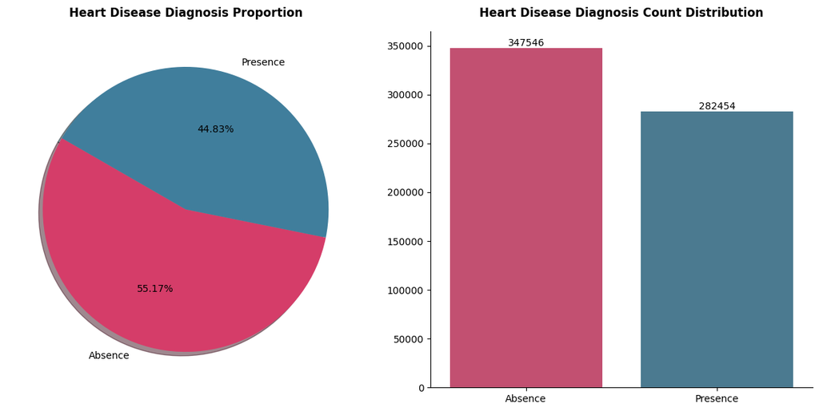

```python
# Prepare data and colors
status_counts = df_train[config.target_feature].value_counts().sort_index()
order = status_counts.index.tolist()
colors = color(n_colors=len(order))
palette = dict(zip(order, colors))

# Create subplots
fig, ax = plt.subplots(1, 2, figsize=(12, 6))

# --- Pie chart ---
ax[0].pie(status_counts, labels=order, colors=colors, autopct="%1.2f%%", startangle=150, shadow=True)
ax[0].set_title("Heart Disease Diagnosis Proportion", fontweight="bold", fontsize=12, pad=15)

# --- Count plot ---
sns.countplot(data=df_train, x=config.target_feature, order=order, palette=palette, ax=ax[1])
ax[1].set_title("Heart Disease Diagnosis Count Distribution", fontweight="bold", fontsize=12, pad=15)
for container in ax[1].containers:
    ax[1].bar_label(container, fmt="%d", label_type="edge", fontsize=10)
ax[1].set(xlabel="", ylabel="")
sns.despine(ax=ax[1])

plt.tight_layout()
plt.show()
```

**Target Distribution (Heart Disease – Train Set)**

- **Majority class**: `Absence` (patients without heart disease)
- **Minority class**: `Presence` (patients with heart disease)
- The target variable is **moderately balanced**, with the positive class representing **~45%** of the data.
- No severe class imbalance is observed → reduces the need for aggressive resampling.
- The relatively high proportion of positive cases reflects a **high-risk clinical population**, making the dataset suitable for medical risk prediction.

## Numerical Feature Distributions

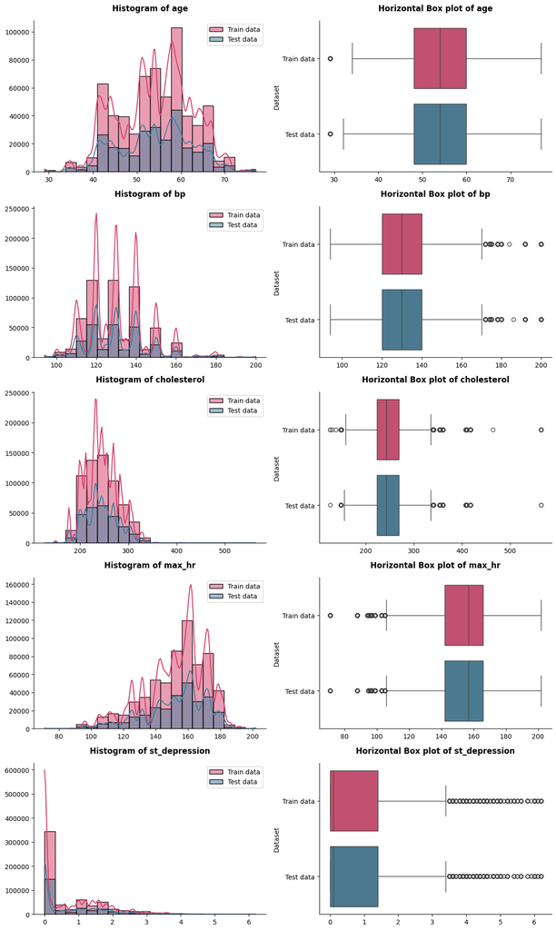

```python
def plot_numerical_features(df_train: pd.DataFrame, df_test: pd.DataFrame,
                            num_features: List[str]):
    """
    Plot histogram and boxplot for each numerical feature.

    - Histogram shows distribution and skewness.
    - Boxplot highlights median and potential outliers.
    """

    colors = color(n_colors=2)  # Generate color palette for 2 datasets
    n = len(num_features)       # Number of numerical features

    # Create subplot grid: each feature has 1 row, 2 columns (hist + boxplot)
    fig, ax = plt.subplots(n, 2, figsize=(12, n * 4))
    ax = np.array(ax).reshape(n, 2) # Ensure consistent array shape

    for i, feature in enumerate(num_features):
         # Histogram + KDE Plot
        sns.histplot(data=df_train[feature], color=colors[0], bins=20, kde=True, ax=ax[i, 0], label="Train data")
        sns.histplot(data=df_test[feature], color=colors[1], bins=20, kde=True, ax=ax[i, 0], label="Test data")
        # Format histogram
        ax[i, 0].set_title(f"Histogram of {feature}", pad=15, weight="bold", fontsize=12)
        ax[i, 0].legend()
        ax[i, 0].set_xlabel("")
        ax[i, 0].set_ylabel("")
        sns.despine(ax=ax[i, 0])

        df_plot = pd.concat([
            pd.DataFrame({"Dataset": "Train data", feature: df_train[feature]}),
            pd.DataFrame({"Dataset": "Test data", feature: df_test[feature]})
        ]).reset_index(drop=True)

        # Prepare Data for Boxplot
        sns.boxplot(
            data=df_plot,
            x=feature,
            y="Dataset",
            palette=colors,
            orient="h",
            ax=ax[i, 1]
        )
        # Format boxplot
        ax[i, 1].set_title(f"Horizontal Box plot of {feature}", pad=15, weight="bold", fontsize=12)
        ax[i, 1].set_xlabel("")
        sns.despine(ax=ax[i, 1])

    # Adjust layout to prevent overlap
    plt.tight_layout()
    plt.show()

plot_numerical_features(df_train = df_train, df_test = df_test, num_features=num_features)
```

```python
def check_skewness(data: pd.DataFrame, dataset_name: str, numerical_features: List[str] =num_features,
                   sort=True, logger: logging.Logger=logger):
    """
    Analyze skewness of numerical features in a dataset and log summary insights.

    This function computes the skewness for each numerical feature, optionally
    sorts them by absolute skewness, and categorizes features based on the
    degree of skewness. Detailed results are logged at DEBUG level, while
    high-level insights and recommendations are logged at INFO level.

    Parameters
    ----------
    data : pandas.DataFrame
        The input dataset containing numerical features to be analyzed.

    dataset_name : str
        A descriptive name of the dataset, used for logging and reporting.

    numerical_features : list of str, optional
        List of numerical feature names to evaluate.
        Default is `num_features`.

    sort : bool, optional (default=True)
        If True, sort features by absolute skewness in descending order.

    logger : logging.Logger
        Logger object used to output analysis results and insights.

    Returns
    -------
    list of str
        A list of feature names that are considered highly skewed
        (|skewness| > 1).

    Notes
    -----
    - Skewness interpretation:
        * |skew| ≤ 0.5  : Approximately symmetric
        * 0.5 < |skew| ≤ 1 : Moderately skewed
        * |skew| > 1   : Highly skewed
    - Highly skewed features may benefit from transformations such as:
        log, Box-Cox, or Yeo-Johnson.
    - This function is intended for exploratory data analysis (EDA)
      and feature preprocessing stages.
    """

    skewness_dict = {}
    skew_features = []
    for feature in numerical_features:
        skew = data[feature].skew(skipna=True)
        skewness_dict[feature] = skew

    skew_df = pd.DataFrame.from_dict(skewness_dict, orient="index", columns=["Skewness"])
    if sort:
        skew_df = skew_df.reindex(skew_df["Skewness"].abs().sort_values(ascending=False).index)

    # ===== Summary header =====
    logger.info(f"Skewness analysis for {dataset_name}")
    logger.info(f"Total numerical features checked: {len(skew_df)}")

    # ===== Detailed table (DEBUG) =====
    logger.debug("-"*70)
    logger.debug(f"{'Feature':<30} | {'Skewness':<9} | {'Remark'}")
    logger.debug("-"*70)
    for feature, row in skew_df.iterrows():
        skew = row["Skewness"]
        abs_skew = abs(skew)
        if abs_skew > 1:
            remark = "Highly skewed"
            skew_features.append(feature)
        elif abs_skew > 0.5:
            remark = "Moderately skewed"
        else:
            remark = "Approximately symmetric"
        logger.debug(f"{feature:<30} | {skew:>+9.4f} | {remark}")
    logger.debug("-" * 70)

    # ===== Summary insight =====
    if skew_features:
        logger.info(f"{len(skew_features)} features are highly skewed (|skew| > 1).")
        logger.info(f"Recommendation: Consider log / Box-Cox / Yeo-Johnson transformation.")
    else:
        logger.info("No highly skewed features detected.")

    return skew_features

skew_feature = check_skewness(df_train, "Heart Disease")
logger.info("-" * 80)
logger.info("Checking skewness successfully completed the dataset.")
```

```
2026-02-02 19:41:55 | INFO | Skewness analysis for Heart Disease
2026-02-02 19:41:55 | INFO | Total numerical features checked: 5
2026-02-02 19:41:55 | DEBUG | ----------------------------------------------------------------------
2026-02-02 19:41:55 | DEBUG | Feature                        | Skewness  | Remark
2026-02-02 19:41:55 | DEBUG | ----------------------------------------------------------------------
2026-02-02 19:41:55 | DEBUG | st_depression                  |   +1.3284 | Highly skewed
2026-02-02 19:41:55 | DEBUG | max_hr                         |   -0.7546 | Moderately skewed
2026-02-02 19:41:55 | DEBUG | bp                             |   +0.6293 | Moderately skewed
2026-02-02 19:41:55 | DEBUG | cholesterol                    |   +0.2731 | Approximately symmetric
2026-02-02 19:41:55 | DEBUG | age                            |   -0.1640 | Approximately symmetric
2026-02-02 19:41:55 | DEBUG | ----------------------------------------------------------------------
2026-02-02 19:41:55 | INFO | 1 features are highly skewed (|skew| > 1).
2026-02-02 19:41:55 | INFO | Recommendation: Consider log / Box-Cox / Yeo-Johnson transformation.
2026-02-02 19:41:55 | INFO | --------------------------------------------------------------------------------
2026-02-02 19:41:55 | INFO | Checking skewness successfully completed the dataset.
```

## Correlation Analysis of Numerical Features

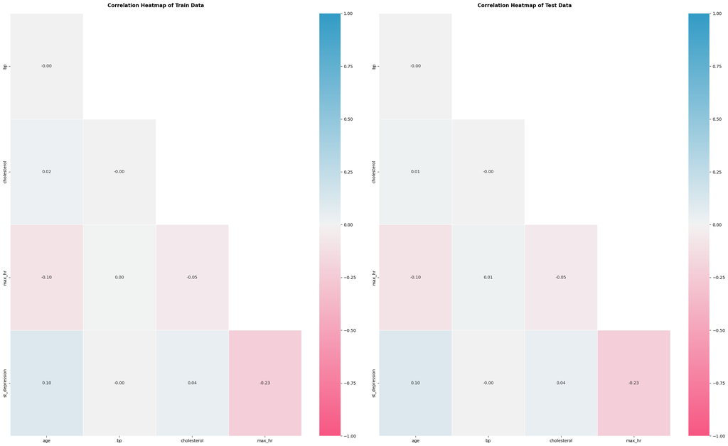

```python
def plot_correlation(df_train: pd.DataFrame, df_test: pd.DataFrame,
                     train_name: str ="Train Data", test_name: str ="Test Data", figsize=(25, 15)) -> None:
    """
    Plot side-by-side correlation heatmaps for training and test datasets.

    This function computes Pearson correlation matrices for numerical features
    in both training and test datasets, applies a triangular mask to avoid
    duplicated information, and visualizes the results using seaborn heatmaps.

    Parameters
    ----------
    df_train : pandas.DataFrame
        Training dataset (features only, target column should be removed).

    df_test : pandas.DataFrame
        Test dataset (features only).

    train_name : str, default="Train Data"
        Title name for the training heatmap.

    test_name : str, default="Test Data"
        Title name for the test heatmap.

    figsize : tuple, default=(25, 15)
        Figure size for the matplotlib plot.

    Returns
    -------
    None
        Displays correlation heatmaps for train and test datasets.
    """

    # Compute correlation matrices (numerical features only)
    corr_train = df_train.corr(numeric_only=True)
    corr_test = df_test.corr(numeric_only=True)

    # Create upper-triangle masks to remove duplicate values
    # (keep only lower triangle of correlation matrix)
    mask_train = np.triu(np.ones_like(corr_train, dtype=bool))
    adjusted_mask_train = mask_train[1:, :-1]
    adjusted_cereal_corr_train = corr_train.iloc[1:, :-1]

    mask_test = np.triu(np.ones_like(corr_test, dtype=bool))
    adjusted_mask_test = mask_test[1:, :-1]
    adjusted_cereal_corr_test = corr_test.iloc[1:, :-1]

    # Define diverging color palette (negative → positive correlation)
    cmap = sns.diverging_palette(0, 230, 90, 60, as_cmap=True)
    # Create subplots for side-by-side visualization
    fig, ax = plt.subplots(1, 2, figsize=figsize)

    # Plot training correlation heatmap
    sns.heatmap(data=adjusted_cereal_corr_train, mask=adjusted_mask_train,
                annot=True, fmt=".2f", cmap=cmap,
                vmin=-1, vmax=1, linecolor="white", linewidths=0.5, ax=ax[0])
    ax[0].set_title(f"Correlation Heatmap of {train_name}", fontsize=12, weight="bold", loc="center", pad=15)

    # Plot test correlation heatmap
    sns.heatmap(data=adjusted_cereal_corr_test, mask=adjusted_mask_test,
                annot=True, fmt=".2f", cmap=cmap,
                vmin=-1, vmax=1, linecolor="white", linewidths=0.5, ax=ax[1])
    ax[1].set_title(f"Correlation Heatmap of {test_name}", fontsize=12, weight="bold", loc="center", pad=15)

    # Adjust layout and display
    plt.tight_layout()
    plt.show()

plot_correlation(df_train=df_train.drop(columns=cat_features_full), df_test=df_test.drop(columns=cat_features))
```

**Correlation Analysis (Numerical Features)**

- Pearson correlation was analyzed for numerical features in both Train and Test datasets.
- Overall, **most feature pairs show very weak correlations** (|r| < 0.2), indicating low multicollinearity.
- **Notable relationships:**
  - `st_depression` vs `max_hr`: moderate negative correlation (**~ −0.23**)
  - `age` vs `max_hr`: weak negative correlation (**~ −0.10**)
- Other feature pairs (e.g., `bp`, `cholesterol`) show **near-zero correlations**.

**Train–Test Consistency**

- Correlation patterns are **nearly identical** in Train and Test.
- No structural changes or relationship drift is observed.

👉 Confirms stable feature relationships across datasets.

**Modeling Implications**

- Low inter-feature correlation reduces the risk of multicollinearity.
- All numerical features can be retained without strong redundancy.
- Suitable for both linear and tree-based models.

## Categorical Feature Distributions

```python
def plot_categorical_distribution_across_datasets(df_train: pd.DataFrame = df_train, df_test: pd.DataFrame = df_test,
                                                  feature: str ="gender", logger: logging.Logger = logger) -> None:

    """
    Display categorical feature distribution comparison
    between training and test datasets.

    Parameters
    ----------
    df_train : pd.DataFrame
        Training dataset.

    df_test : pd.DataFrame
        Test dataset.

    feature : str
        Categorical feature name.

    logger : logging.Logger
        Logger instance.
    """

    logger.info(f"Analyzing categorical feature: {feature}")
    # Summarize categorical feature in training set
    train_summary = (
        df_train[feature]
        .value_counts()
        .rename_axis("Category")
        .reset_index(name="Train_Count")
    )

    # Calculate percentage distribution in training data
    train_summary["Train_%"] = round((train_summary["Train_Count"] / train_summary["Train_Count"].sum() * 100), 2)

    # Summarize categorical feature in test set
    test_summary = (
        df_test[feature]
        .value_counts()
        .rename_axis("Category")
        .reset_index(name="Test_Count")
    )

    # Calculate percentage distribution in test data
    test_summary["Test_%"] = round((test_summary["Test_Count"] / test_summary["Test_Count"].sum() * 100), 2)

    # Merge train and test summaries for comparison
    summary = pd.merge(train_summary, test_summary, on="Category", how="inner")

    logger.debug(f"{feature}: {len(summary)} categories detected")

    # Ensure Category column is of string type before handling missing values
    summary["Category"] = summary["Category"].astype(str)

    # Fill missing values only for numeric columns
    cat_cols = ["Train_Count", "Train_%", "Test_Count", "Test_%"]
    summary[cat_cols] = summary[cat_cols].fillna(0)

    # Convert summary table to HTML for better visualization in notebook
    html = summary.to_html(
        index=False,
        justify="center",
        classes="table table-striped table-hover",
    )

    # Display formatted HTML table with title
    display(HTML(f"[✓] Categorical Feature Distribution: <b>{feature}</b>" + html))

    logger.info(f"Completed analysis for: {feature}")
    logger.info("*" * 80)

# ----- Run the function for all categorical features -----
for feature in cat_features:
    plot_categorical_distribution_across_datasets(df_train=df_train, df_test=df_test, feature=feature)
```

```
2026-02-02 19:41:56 | INFO | Analyzing categorical feature: sex
2026-02-02 19:41:56 | DEBUG | sex: 2 categories detected
```

[✓] Categorical Feature Distribution: **sex**

| Category | Train_Count | Train_% | Test_Count | Test_% |
| --- | --- | --- | --- | --- |
| 1 | 450283 | 71.47 | 193405 | 71.63 |
| 0 | 179717 | 28.53 | 76595 | 28.37 |

```
2026-02-02 19:41:56 | INFO | Completed analysis for: sex
2026-02-02 19:41:56 | INFO | ********************************************************************************
2026-02-02 19:41:56 | INFO | Analyzing categorical feature: chest_pain_type
2026-02-02 19:41:56 | DEBUG | chest_pain_type: 4 categories detected
```

[✓] Categorical Feature Distribution: **chest_pain_type**

| Category | Train_Count | Train_% | Test_Count | Test_% |
| --- | --- | --- | --- | --- |
| 4 | 329179 | 52.25 | 141641 | 52.46 |
| 3 | 197278 | 31.31 | 84042 | 31.13 |
| 2 | 74941 | 11.90 | 32072 | 11.88 |
| 1 | 28602 | 4.54 | 12245 | 4.54 |

```
2026-02-02 19:41:56 | INFO | Completed analysis for: chest_pain_type
2026-02-02 19:41:56 | INFO | ********************************************************************************
2026-02-02 19:41:56 | INFO | Analyzing categorical feature: fbs_over_120
2026-02-02 19:41:56 | DEBUG | fbs_over_120: 2 categories detected
```

[✓] Categorical Feature Distribution: **fbs_over_120**

| Category | Train_Count | Train_% | Test_Count | Test_% |
| --- | --- | --- | --- | --- |
| 0 | 579608 | 92.0 | 248386 | 91.99 |
| 1 | 50392 | 8.0 | 21614 | 8.01 |

```
2026-02-02 19:41:56 | INFO | Completed analysis for: fbs_over_120
2026-02-02 19:41:56 | INFO | ********************************************************************************
2026-02-02 19:41:56 | INFO | Analyzing categorical feature: ekg_results
2026-02-02 19:41:56 | DEBUG | ekg_results: 3 categories detected
```

[✓] Categorical Feature Distribution: **ekg_results**

| Category | Train_Count | Train_% | Test_Count | Test_% |
| --- | --- | --- | --- | --- |
| 0 | 320116 | 50.81 | 137611 | 50.97 |
| 2 | 308562 | 48.98 | 131804 | 48.82 |
| 1 | 1322 | 0.21 | 585 | 0.22 |

```
2026-02-02 19:41:56 | INFO | Completed analysis for: ekg_results
2026-02-02 19:41:56 | INFO | ********************************************************************************
2026-02-02 19:41:56 | INFO | Analyzing categorical feature: exercise_angina
2026-02-02 19:41:56 | DEBUG | exercise_angina: 2 categories detected
```

[✓] Categorical Feature Distribution: **exercise_angina**

| Category | Train_Count | Train_% | Test_Count | Test_% |
| --- | --- | --- | --- | --- |
| 0 | 457553 | 72.63 | 195843 | 72.53 |
| 1 | 172447 | 27.37 | 74157 | 27.47 |

```
2026-02-02 19:41:56 | INFO | Completed analysis for: exercise_angina
2026-02-02 19:41:56 | INFO | ********************************************************************************
2026-02-02 19:41:56 | INFO | Analyzing categorical feature: slope_of_st
2026-02-02 19:41:56 | DEBUG | slope_of_st: 3 categories detected
```

[✓] Categorical Feature Distribution: **slope_of_st**

| Category | Train_Count | Train_% | Test_Count | Test_% |
| --- | --- | --- | --- | --- |
| 1 | 358293 | 56.87 | 152720 | 56.56 |
| 2 | 256215 | 40.67 | 110534 | 40.94 |
| 3 | 15492 | 2.46 | 6746 | 2.50 |

```
2026-02-02 19:41:56 | INFO | Completed analysis for: slope_of_st
2026-02-02 19:41:56 | INFO | ********************************************************************************
2026-02-02 19:41:56 | INFO | Analyzing categorical feature: number_of_vessels_fluro
2026-02-02 19:41:56 | DEBUG | number_of_vessels_fluro: 4 categories detected
```

[✓] Categorical Feature Distribution: **number_of_vessels_fluro**

| Category | Train_Count | Train_% | Test_Count | Test_% |
| --- | --- | --- | --- | --- |
| 0 | 445862 | 70.77 | 190487 | 70.55 |
| 1 | 106978 | 16.98 | 46147 | 17.09 |
| 2 | 54303 | 8.62 | 23449 | 8.68 |
| 3 | 22857 | 3.63 | 9917 | 3.67 |

```
2026-02-02 19:41:56 | INFO | Completed analysis for: number_of_vessels_fluro
2026-02-02 19:41:56 | INFO | ********************************************************************************
2026-02-02 19:41:56 | INFO | Analyzing categorical feature: thallium
2026-02-02 19:41:56 | DEBUG | thallium: 3 categories detected
```

[✓] Categorical Feature Distribution: **thallium**

| Category | Train_Count | Train_% | Test_Count | Test_% |
| --- | --- | --- | --- | --- |
| 3 | 372286 | 59.09 | 159498 | 59.07 |
| 7 | 246748 | 39.17 | 105833 | 39.20 |
| 6 | 10966 | 1.74 | 4669 | 1.73 |

```
2026-02-02 19:41:56 | INFO | Completed analysis for: thallium
2026-02-02 19:41:56 | INFO | ********************************************************************************
```

```python
def top_ratio(df_train: pd.DataFrame, df_test: pd.DataFrame,
              cat_features: List[str], logger: logging.Logger) -> None:
    """
    Identify categorical features dominated by a single category.

    This function checks whether any categorical feature has a dominant
    category accounting for more than 99% of its values in the
    training or test dataset.

    Such features have very low variance and may contribute little
    predictive power to machine learning models.

    Parameters
    ----------
    df_train : pd.DataFrame
        Training dataset.

    df_test : pd.DataFrame
        Test dataset.

    cat_features : List[str]
        List of categorical feature names.

    logger : logging.Logger
        Logger instance for logging results.

    Returns
    -------
    None
        Results are logged to the console.
    """

    dataset_names = ["Train", "Test"]
    datasets = [df_train, df_test]

    # Iterate through each dataset
    for data, name in zip(datasets, dataset_names):
        logger.info(f"{name} Data")
        flagged = False  # Track whether any dominant category is detected
        # Check each categorical feature
        for feature in cat_features:
            # Compute normalized frequency of categories
            freq = data[feature].value_counts(normalize=True)
            # Ratio of most frequent category
            top_ratio = freq.iloc[0]
            # Flag features dominated by one category (>99%)
            if top_ratio > 0.99:
                flagged = True
                logger.info(f"{feature}: {top_ratio:.1%} is '{freq.index[0]}'")

        # Log if no highly dominant feature is found
        if not flagged:
            logger.info("No feature has a category that makes up more than 99% of its values.")
        logger.info("-" * 80)

top_ratio(df_train=df_train, df_test=df_test, cat_features=cat_features, logger=logger)
```

```
2026-02-02 19:41:56 | INFO | Train Data
2026-02-02 19:41:56 | INFO | No feature has a category that makes up more than 99% of its values.
2026-02-02 19:41:56 | INFO | --------------------------------------------------------------------------------
2026-02-02 19:41:56 | INFO | Test Data
2026-02-02 19:41:56 | INFO | No feature has a category that makes up more than 99% of its values.
2026-02-02 19:41:56 | INFO | --------------------------------------------------------------------------------
```

**Overall Consistency in Categorical Feature Distributions**

> The categorical features exhibit a **high degree of distributional similarity between the Training and Test datasets**, indicating **well-preserved sampling consistency**.  
> Category proportions remain highly stable across all major clinical indicators, with no dominant class exceeding **99%**.  
> This stability reduces the risk of dataset mismatch and supports **robust and reliable model generalization**.

## Bivariate Analysis

- **Overall Mean:** 54.14

- **Overall Median:** 54.0

- **Overall Std:** 8.26

|  | heart_disease | Count | Mean | Median | Std |
| --- | --- | --- | --- | --- | --- |
| 0 | Presence | 282454 | 56.079114 | 57.000000 | 7.768723 |
| 1 | Absence | 347546 | 52.558093 | 52.000000 | 8.304120 |

```
2026-02-02 19:41:57 | INFO | Checking normality of feature 'age' by groups of 'heart_disease'...
2026-02-02 19:41:57 | INFO | Evaluating distribution characteristics (skewness & kurtosis)...
2026-02-02 19:41:57 | DEBUG | Number of groups detected: 2
2026-02-02 19:41:57 | DEBUG | Thresholds → |skew|≤0.5, |kurtosis|≤1.5
2026-02-02 19:41:57 | DEBUG | [heart_disease=Absence] skew=0.0392, kurtosis=-0.6382 → Approximately symmetric, Normal tails
2026-02-02 19:41:57 | DEBUG | [heart_disease=Presence] skew=-0.3963, kurtosis=-0.1654 → Approximately symmetric, Normal tails
2026-02-02 19:41:57 | INFO | Generating Q–Q plots for visual assessment...
```

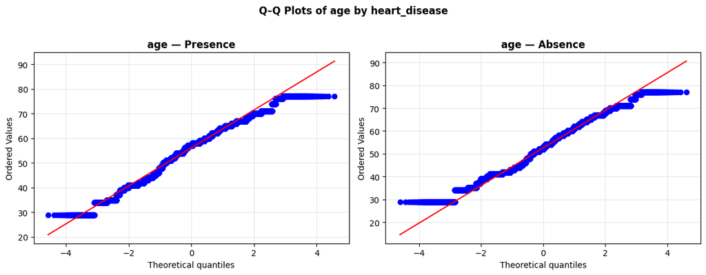

**Skewness & Kurtosis of age by heart_disease**

|  | Feature | Group | Skewness | Kurtosis | Remark |
| --- | --- | --- | --- | --- | --- |
| 0 | age | Absence | 0.0392 | -0.6382 | Approximately symmetric, Normal tails |
| 1 | age | Presence | -0.3963 | -0.1654 | Approximately symmetric, Normal tails |

```
2026-02-02 19:41:58 | INFO | All groups approximately follow a normal distribution.
2026-02-02 19:41:59 | INFO | Check homogeneity of variances across groups using Levene’s test (median-centered)
2026-02-02 19:41:59 | DEBUG | Number of groups detected: 2
```

**Homogeneity of Variance — age by heart_disease**

|  | Metric | Value |
| --- | --- | --- |
| 0 | Levene’s Statistic | 3689.9490 |
| 1 | p-value | 0.000000 |
| 2 | Max/Min Variance Ratio | 1.14 |

```
2026-02-02 19:41:59 | INFO | Interpretation:
2026-02-02 19:41:59 | INFO | - Status: Statistically different variances, but practical difference is small.
2026-02-02 19:41:59 | INFO | - Recommendation: ANOVA or T-Test are acceptable, but Welch’s ANOVA or Welch’s T-Test is recommended.
2026-02-02 19:41:59 | INFO | Running Independent Two-Sample T-Test: 'age' ~ 'heart_disease'
2026-02-02 19:41:59 | DEBUG | Number of groups detected: 2
2026-02-02 19:41:59 | DEBUG | Test Type: Welch’s T-Test (unequal variances)
2026-02-02 19:41:59 | INFO | Comparing groups: 'Presence' vs 'Absence'
2026-02-02 19:41:59 | INFO | p-value: 0.000000
2026-02-02 19:41:59 | INFO | Cohen's d: 0.438
2026-02-02 19:41:59 | DEBUG | t-statistic: 173.449
2026-02-02 19:41:59 | DEBUG | Group means → Presence: 56.079, Absence: 52.558
2026-02-02 19:41:59 | INFO | Result: p-value ≤ 0.05 → Reject H0
2026-02-02 19:41:59 | INFO | Conclusion: Significant difference between the two groups.
2026-02-02 19:41:59 | INFO | Effect size interpretation: medium effect (|d| = 0.438)
```

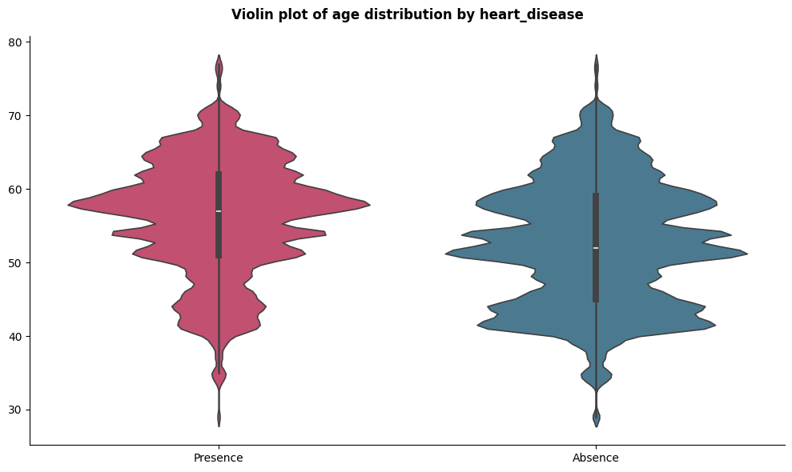

- **Overall Mean:** 130.50

- **Overall Median:** 130.0

- **Overall Std:** 14.98

|  | heart_disease | Count | Mean | Median | Std |
| --- | --- | --- | --- | --- | --- |
| 0 | Absence | 347546 | 130.567381 | 130.000000 | 15.135647 |
| 1 | Presence | 282454 | 130.411366 | 130.000000 | 14.776321 |

```
2026-02-02 19:42:02 | INFO | Checking normality of feature 'bp' by groups of 'heart_disease'...
2026-02-02 19:42:02 | INFO | Evaluating distribution characteristics (skewness & kurtosis)...
2026-02-02 19:42:02 | DEBUG | Number of groups detected: 2
2026-02-02 19:42:02 | DEBUG | Thresholds → |skew|≤0.5, |kurtosis|≤1.5
2026-02-02 19:42:02 | DEBUG | [heart_disease=Absence] skew=0.6716, kurtosis=0.9987 → Moderately skewed, Normal tails
2026-02-02 19:42:02 | DEBUG | [heart_disease=Presence] skew=0.5722, kurtosis=0.8357 → Moderately skewed, Normal tails
2026-02-02 19:42:02 | INFO | Generating Q–Q plots for visual assessment...
```

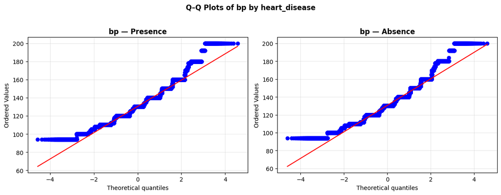

**Skewness & Kurtosis of bp by heart_disease**

|  | Feature | Group | Skewness | Kurtosis | Remark |
| --- | --- | --- | --- | --- | --- |
| 0 | bp | Absence | 0.6716 | 0.9987 | Moderately skewed, Normal tails |
| 1 | bp | Presence | 0.5722 | 0.8357 | Moderately skewed, Normal tails |

```
2026-02-02 19:42:04 | WARNING | Normality assumption violated in at least one group.
2026-02-02 19:42:04 | INFO | Recommendation: Use non-parametric tests (Kruskal–Wallis / Mann–Whitney U).
2026-02-02 19:42:04 | INFO | Running Mann–Whitney U Test: 'bp' by 'heart_disease'...
2026-02-02 19:42:04 | DEBUG | Number of groups detected: 2
2026-02-02 19:42:04 | INFO | U statistic: 49130564546.0
2026-02-02 19:42:04 | INFO | p-value    : 0.503108
2026-02-02 19:42:04 | WARNING | Result: p-value > 0.05 → Fail to reject H0
2026-02-02 19:42:04 | WARNING | Conclusion: No statistically significant difference detected.
```

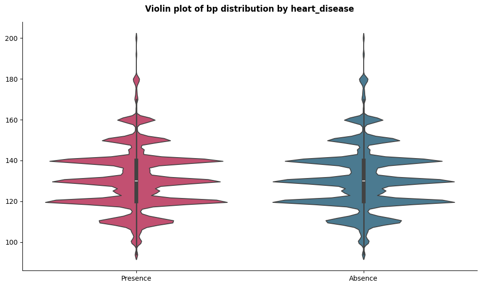

- **Overall Mean:** 245.01

- **Overall Median:** 243.0

- **Overall Std:** 33.68

|  | heart_disease | Count | Mean | Median | Std |
| --- | --- | --- | --- | --- | --- |
| 0 | Presence | 282454 | 248.103585 | 246.000000 | 32.922645 |
| 1 | Absence | 347546 | 242.499102 | 239.000000 | 34.080064 |

```
2026-02-02 19:42:07 | INFO | Checking normality of feature 'cholesterol' by groups of 'heart_disease'...
2026-02-02 19:42:07 | INFO | Evaluating distribution characteristics (skewness & kurtosis)...
2026-02-02 19:42:07 | DEBUG | Number of groups detected: 2
2026-02-02 19:42:07 | DEBUG | Thresholds → |skew|≤0.5, |kurtosis|≤1.5
2026-02-02 19:42:07 | DEBUG | [heart_disease=Absence] skew=0.3972, kurtosis=0.2920 → Approximately symmetric, Normal tails
2026-02-02 19:42:07 | DEBUG | [heart_disease=Presence] skew=0.1301, kurtosis=-0.1368 → Approximately symmetric, Normal tails
2026-02-02 19:42:07 | INFO | Generating Q–Q plots for visual assessment...
```

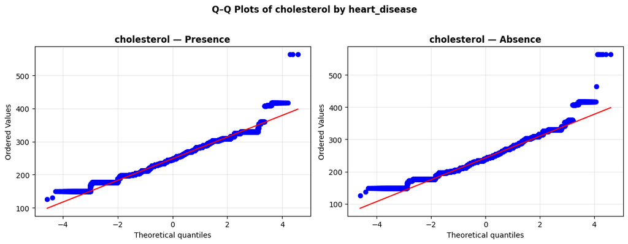

**Skewness & Kurtosis of cholesterol by heart_disease**

|  | Feature | Group | Skewness | Kurtosis | Remark |
| --- | --- | --- | --- | --- | --- |
| 0 | cholesterol | Absence | 0.3972 | 0.2920 | Approximately symmetric, Normal tails |
| 1 | cholesterol | Presence | 0.1301 | -0.1368 | Approximately symmetric, Normal tails |

```
2026-02-02 19:42:09 | INFO | All groups approximately follow a normal distribution.
2026-02-02 19:42:09 | INFO | Check homogeneity of variances across groups using Levene’s test (median-centered)
2026-02-02 19:42:09 | DEBUG | Number of groups detected: 2
```

**Homogeneity of Variance — cholesterol by heart_disease**

|  | Metric | Value |
| --- | --- | --- |
| 0 | Levene’s Statistic | 36.7391 |
| 1 | p-value | 0.000000 |
| 2 | Max/Min Variance Ratio | 1.07 |

```
2026-02-02 19:42:09 | INFO | Interpretation:
2026-02-02 19:42:09 | INFO | - Status: Statistically different variances, but practical difference is small.
2026-02-02 19:42:09 | INFO | - Recommendation: ANOVA or T-Test are acceptable, but Welch’s ANOVA or Welch’s T-Test is recommended.
2026-02-02 19:42:09 | INFO | Running Independent Two-Sample T-Test: 'cholesterol' ~ 'heart_disease'
2026-02-02 19:42:09 | DEBUG | Number of groups detected: 2
2026-02-02 19:42:09 | DEBUG | Test Type: Welch’s T-Test (unequal variances)
2026-02-02 19:42:09 | INFO | Comparing groups: 'Presence' vs 'Absence'
2026-02-02 19:42:09 | INFO | p-value: 0.000000
2026-02-02 19:42:09 | INFO | Cohen's d: 0.167
2026-02-02 19:42:09 | DEBUG | t-statistic: 66.145
2026-02-02 19:42:09 | DEBUG | Group means → Presence: 248.104, Absence: 242.499
2026-02-02 19:42:09 | INFO | Result: p-value ≤ 0.05 → Reject H0
2026-02-02 19:42:09 | INFO | Conclusion: Significant difference between the two groups.
2026-02-02 19:42:09 | INFO | Effect size interpretation: small effect (|d| = 0.167)
```

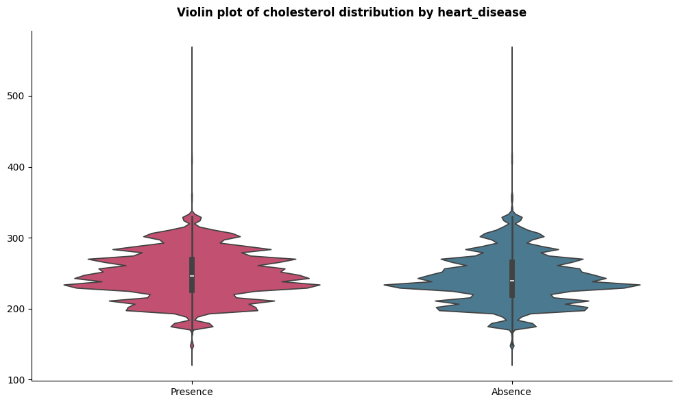

- **Overall Mean:** 152.82

- **Overall Median:** 157.0

- **Overall Std:** 19.11

|  | heart_disease | Count | Mean | Median | Std |
| --- | --- | --- | --- | --- | --- |
| 0 | Absence | 347546 | 160.415105 | 162.000000 | 14.740398 |
| 1 | Presence | 282454 | 143.467372 | 146.000000 | 19.722854 |

```
2026-02-02 19:42:12 | INFO | Checking normality of feature 'max_hr' by groups of 'heart_disease'...
2026-02-02 19:42:12 | INFO | Evaluating distribution characteristics (skewness & kurtosis)...
2026-02-02 19:42:12 | DEBUG | Number of groups detected: 2
2026-02-02 19:42:12 | DEBUG | Thresholds → |skew|≤0.5, |kurtosis|≤1.5
2026-02-02 19:42:12 | DEBUG | [heart_disease=Absence] skew=-0.8202, kurtosis=0.9745 → Moderately skewed, Normal tails
2026-02-02 19:42:12 | DEBUG | [heart_disease=Presence] skew=-0.4464, kurtosis=-0.4587 → Approximately symmetric, Normal tails
2026-02-02 19:42:12 | INFO | Generating Q–Q plots for visual assessment...
```

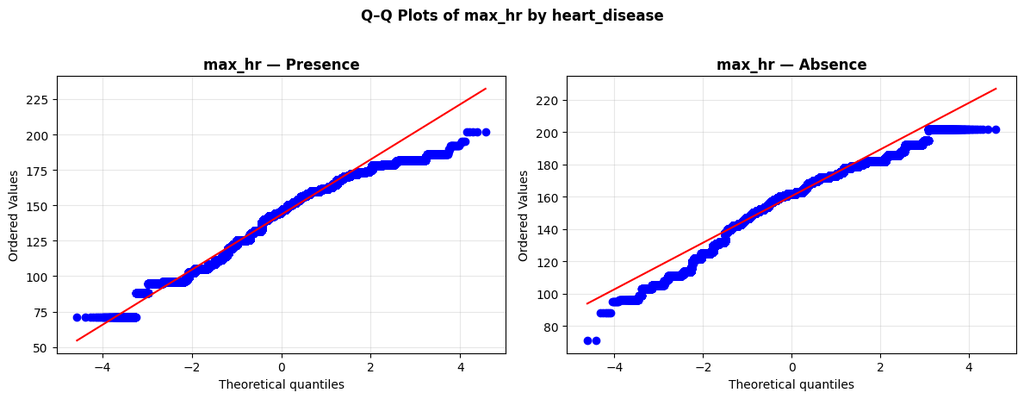

**Skewness & Kurtosis of max_hr by heart_disease**

|  | Feature | Group | Skewness | Kurtosis | Remark |
| --- | --- | --- | --- | --- | --- |
| 0 | max_hr | Absence | -0.8202 | 0.9745 | Moderately skewed, Normal tails |
| 1 | max_hr | Presence | -0.4464 | -0.4587 | Approximately symmetric, Normal tails |

```
2026-02-02 19:42:14 | WARNING | Normality assumption violated in at least one group.
2026-02-02 19:42:14 | INFO | Recommendation: Use non-parametric tests (Kruskal–Wallis / Mann–Whitney U).
2026-02-02 19:42:14 | INFO | Running Mann–Whitney U Test: 'max_hr' by 'heart_disease'...
2026-02-02 19:42:14 | DEBUG | Number of groups detected: 2
2026-02-02 19:42:14 | INFO | U statistic: 23961472932.5
2026-02-02 19:42:14 | INFO | p-value    : 0.000000
2026-02-02 19:42:14 | INFO | Result: p-value ≤ 0.05 → Reject H0
2026-02-02 19:42:14 | INFO | Conclusion: Significant difference between the two groups.
2026-02-02 19:42:14 | INFO | Effect size interpretation: Medium
```

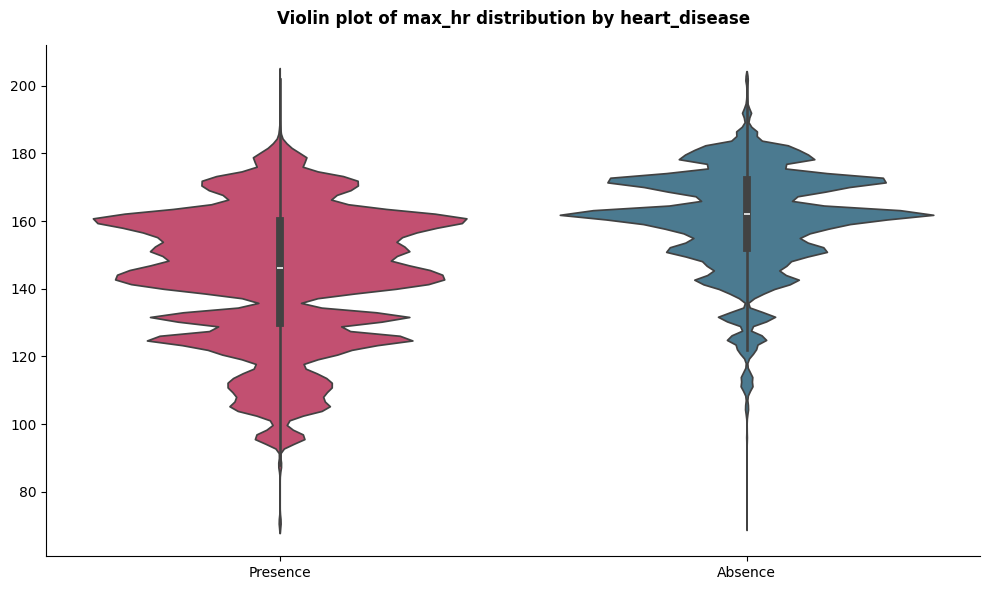

- **Overall Mean:** 0.72

- **Overall Median:** 0.1

- **Overall Std:** 0.95

|  | heart_disease | Count | Mean | Median | Std |
| --- | --- | --- | --- | --- | --- |
| 0 | Presence | 282454 | 1.169104 | 1.200000 | 1.066893 |
| 1 | Absence | 347546 | 0.347808 | 0.000000 | 0.634996 |

```
2026-02-02 19:42:18 | INFO | Checking normality of feature 'st_depression' by groups of 'heart_disease'...
2026-02-02 19:42:18 | INFO | Evaluating distribution characteristics (skewness & kurtosis)...
2026-02-02 19:42:18 | DEBUG | Number of groups detected: 2
2026-02-02 19:42:18 | DEBUG | Thresholds → |skew|≤0.5, |kurtosis|≤1.5
2026-02-02 19:42:18 | DEBUG | [heart_disease=Absence] skew=2.1361, kurtosis=4.9839 → Highly skewed, Heavy/light tails
2026-02-02 19:42:18 | DEBUG | [heart_disease=Presence] skew=0.6789, kurtosis=0.0303 → Moderately skewed, Normal tails
2026-02-02 19:42:18 | INFO | Generating Q–Q plots for visual assessment...
```

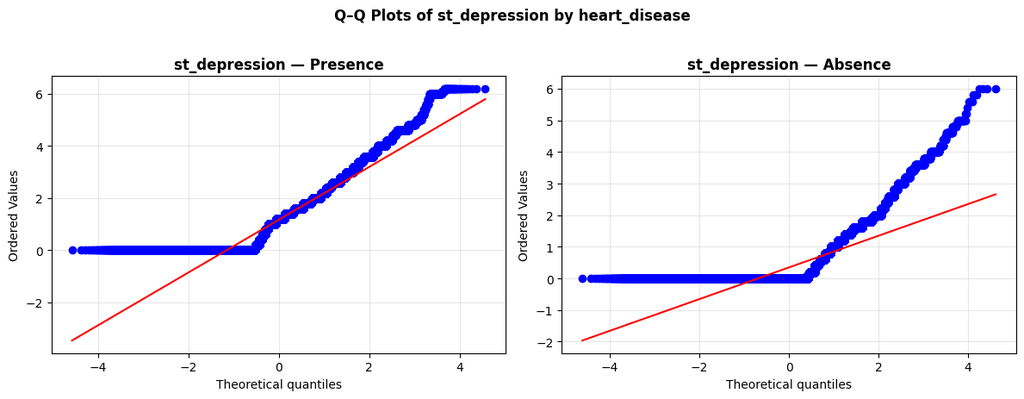

**Skewness & Kurtosis of st_depression by heart_disease**

|  | Feature | Group | Skewness | Kurtosis | Remark |
| --- | --- | --- | --- | --- | --- |
| 0 | st_depression | Absence | 2.1361 | 4.9839 | Highly skewed, Heavy/light tails |
| 1 | st_depression | Presence | 0.6789 | 0.0303 | Moderately skewed, Normal tails |

```
2026-02-02 19:42:20 | WARNING | Normality assumption violated in at least one group.
2026-02-02 19:42:20 | INFO | Recommendation: Use non-parametric tests (Kruskal–Wallis / Mann–Whitney U).
2026-02-02 19:42:20 | INFO | Running Mann–Whitney U Test: 'st_depression' by 'heart_disease'...
2026-02-02 19:42:20 | DEBUG | Number of groups detected: 2
2026-02-02 19:42:20 | INFO | U statistic: 72022016704.5
2026-02-02 19:42:20 | INFO | p-value    : 0.000000
2026-02-02 19:42:20 | INFO | Result: p-value ≤ 0.05 → Reject H0
2026-02-02 19:42:20 | INFO | Conclusion: Significant difference between the two groups.
2026-02-02 19:42:20 | INFO | Effect size interpretation: Medium
```

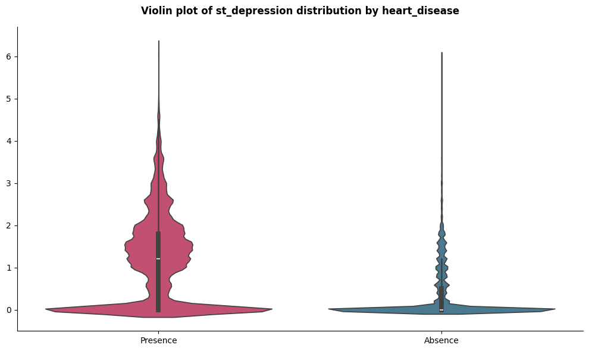

```python
def perform_statical_testing(feature: str, df: pd.DataFrame = df_train,  target_feature: str = config.target_feature) -> None:
    """
    Automatically select and perform appropriate statistical tests
    for comparing a numerical feature across categorical groups.

    This function implements a decision-based statistical testing pipeline
    that selects parametric or non-parametric tests based on:

    - Distribution normality (via skewness, kurtosis, and Q–Q plots)
    - Homogeneity of variances
    - Number of categorical groups

    The procedure follows standard statistical analysis guidelines:

    1. Check normality of the numerical feature within each group.
    2. Determine the number of comparison groups.
    3. Evaluate homogeneity of variance when parametric tests are applicable.
    4. Select and execute the most appropriate hypothesis test.

    Decision Logic
    --------------
    For more than two groups:

    - Non-normal distribution → Kruskal–Wallis test
    - Normal + equal variances → One-way ANOVA + Tukey HSD
    - Normal + unequal variances → Welch’s ANOVA
    - Otherwise → Kruskal–Wallis test

    For two groups:

    - Non-normal distribution → Mann–Whitney U test
    - Normal + equal variances → Independent t-test (with Cohen’s d)
    - Normal + unequal variances → Welch’s t-test (with Cohen’s d)
    - Otherwise → Mann–Whitney U test

    The function also reports effect sizes and post-hoc comparisons
    where applicable.

    Parameters
    ----------
    feature : str
        Name of the numerical feature to be analyzed.

    df : pandas.DataFrame, default=df_train
        Dataset containing the numerical feature and categorical target.

    target_feature : str, default=config.target_feature
        Categorical variable defining comparison groups.

    Returns
    -------
    None
        Executes statistical tests and logs/prints results.
        No value is returned.

    Notes
    -----
    - This function is designed for exploratory and confirmatory
      statistical analysis in machine learning and research workflows.
    - Assumption checks (normality and homoscedasticity) are performed
      automatically prior to testing.
    - For small sample sizes, non-parametric tests are generally preferred.

    Examples
    --------
    >>> perform_statical_testing(
    ...     feature="cholesterol",
    ...     df=df_train,
    ...     target_feature="heart_disease"
    ... )
    """

    # Step 1: Check normality of the feature in each group
    non_normal_detected = check_normality_with_plots(df=df, feature=feature, target_feature=target_feature)
    # Count number of categories in target feature
    total_categories = df[target_feature].nunique()
    # Case 1: More than two groups (Multi-class comparison)
    if total_categories > 2:
        # If data is not normally distributed → use Kruskal–Wallis
        if non_normal_detected:
            perform_kruskal_test(df=df, categorical_feature=target_feature,
                                numeric_feature=feature)
        # If data is approximately normal → check variance homogeneity
        else:
            anove_use, is_homogeneous_variances = check_homogeneity_of_variance(df=df, feature=feature,
                                                                                target_feature=target_feature)
            # Normal + equal variance → One-way ANOVA + Tukey test
            if anove_use and is_homogeneous_variances:
                perform_anova_with_tukey(df=df, numeric_feature=feature,
                                        categorical_feature=target_feature)
            # Normal + unequal variance → Welch ANOVA
            elif anove_use and is_homogeneous_variances == False:
                perform_welch_anova(df=df, numeric_feature=feature, categorical_feature=target_feature)
            # Otherwise → fallback to Kruskal–Wallis
            else:
                perform_kruskal_test(df=df, categorical_feature=target_feature,
                        numeric_feature=feature)
    # Case 2: Two groups (Binary comparison)
    else:
        # If data is not normal → use Mann–Whitney U test
        if non_normal_detected:
            cal_mannwhitneyu(dataframe=df, categorical_feature=target_feature, num_feature=feature)
        # If data is approximately normal → check variance homogeneity
        else:
            anove_use, is_homogeneous_variances = check_homogeneity_of_variance(df=df, feature=feature,
                                                                                target_feature=target_feature)
            # Normal + equal variance → Independent t-test + Cohen's d
            if anove_use and is_homogeneous_variances:
                t_test_with_cohens_d(data=df, categorical_feature=target_feature, num_feature=feature, equal_var=True)
            # Normal + unequal variance → Welch t-test + Cohen's d
            elif anove_use and is_homogeneous_variances == False:
                t_test_with_cohens_d(data=df, categorical_feature=target_feature, num_feature=feature, equal_var=False)
            # Otherwise → fallback to Mann–Whitney U
            else:
                cal_mannwhitneyu(dataframe=df, categorical_feature=target_feature, num_feature=feature)

def plot_numerical_distribution(feature: str, df: pd.DataFrame = df_train,
                                target_feature: str = config.target_feature, order: list = None) -> None:
    """
    Analyze and visualize the distribution of a numerical feature
    across categories of a target variable.

    This function performs:
    - Descriptive statistics (mean, median, std) by group
    - Overall summary statistics
    - Automated statistical hypothesis testing
    - Violin plot visualization

    Parameters
    ----------
    feature : str
        Numerical feature to be analyzed.

    df : pandas.DataFrame
        Input dataset containing the feature and target variable.

    target_feature : str
        Categorical variable used for grouping.

    order : list, optional
        Custom order of categories for plotting.

    Returns
    -------
    None
        Displays summary tables, test results, and plots.
    """

    # Compute summary statistics for each Fertilizer category
    df_summary_feature = (
        df.groupby(by=target_feature, as_index=False)
        .agg(
            Count=(feature, "count"),
            Mean=(feature, "mean"),
            Median=(feature, "median"),
            Std=(feature, "std")
        )
        .sort_values(by="Mean", ascending=False).reset_index(drop=True)
    )

    # Compute global statistics for the entire feature
    summary_data = [
        ("Overall Mean", f"{df[feature].mean():.2f}"),
        ("Overall Median", f"{df[feature].median()}"),
        ("Overall Std", f"{df[feature].std():.2f}")
    ]

    # Display overall statistics in HTML format for better notebook visualization
    summary_html = "<ul>" + "".join([
        f"<li><b>{k}:</b> {v}</li>" for k, v in summary_data
    ]) + "</ul>"
    display(HTML(summary_html))

    # Display detailed summary per category as styled dataframe
    display(
        df_summary_feature.style.background_gradient(cmap=cm)
        .set_table_attributes('style="width:75%; margin:auto;"')
    )

    # Run statistical significance testing
    perform_statical_testing(feature=feature, target_feature=target_feature)

    # Visualize distribution via violin plot
    plt.figure(figsize=(10, 6))
    sns.violinplot(x=target_feature, y=feature, data=df, hue=target_feature, order=order,
                   palette=color(n_colors=df[target_feature].nunique()))

    plt.title(f"Violin plot of {feature} distribution by {target_feature}", pad=15, weight="bold", fontsize=12)
    plt.xlabel("")
    plt.ylabel("")
    plt.legend().remove()
    sns.despine(left=False, bottom=False)
    plt.tight_layout()
    plt.show()

for feature in num_features:
    display(HTML(f"<h2 style='text-align:center; font-size:22px; color:blue;'><b>Distribution of {feature} by Diagnosed Diabetes</b></h2>"))
    plot_numerical_distribution(feature=feature, df = df_train)
```

### Insight Numerical Features vs Heart Disease

- **Age** Patients with heart disease are significantly older on average, confirming age as a key risk factor.
- **Blood Pressure (BP)** No statistically significant difference is observed between groups, suggesting limited standalone impact.
- **Cholesterol** Although slightly higher in diseased patients, the practical effect is small, indicating weak independent predictive power.
- **Maximum Heart Rate (Max HR)** Diseased patients show significantly lower exercise heart rates, reflecting reduced cardiac capacity and strong predictive value.
- **ST Depression** Significantly higher in heart disease patients, indicating myocardial ischemia and serving as a strong clinical indicator.

**Distribution of sex by heart_disease**

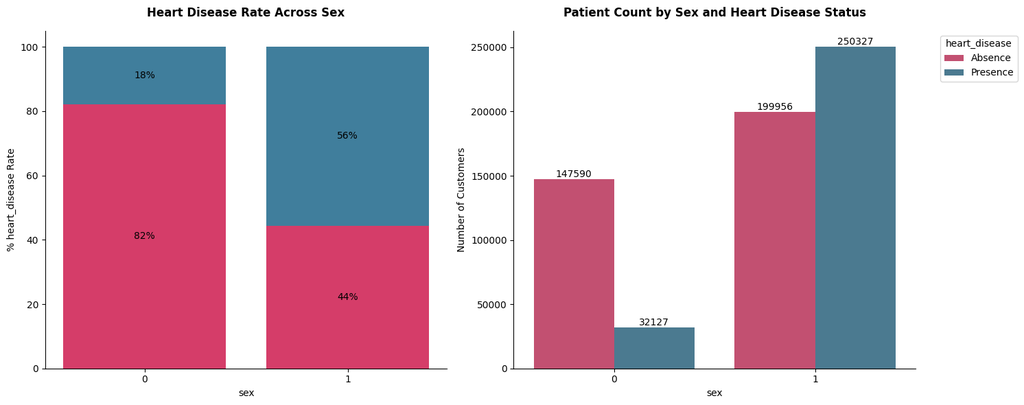

```
2026-02-02 19:42:24 | INFO | Chi-Square Test of Independence: 'sex' vs. 'heart_disease'...
2026-02-02 19:42:24 | INFO | Chi-squared statistic: 73878.222
2026-02-02 19:42:24 | INFO | Degrees of freedom: 1
2026-02-02 19:42:24 | INFO | p-value: 0.000000
2026-02-02 19:42:24 | INFO | Result: p-value < 0.05 → Reject H₀
2026-02-02 19:42:24 | INFO | Variables 'sex' and 'heart_disease' are statistically associated.
2026-02-02 19:42:24 | DEBUG | Displaying standardized residuals heatmap.
```

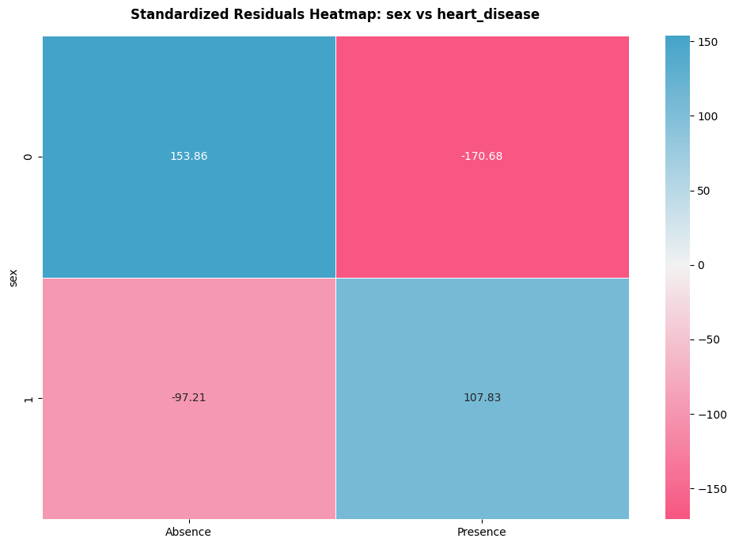

**Distribution of chest_pain_type by heart_disease**

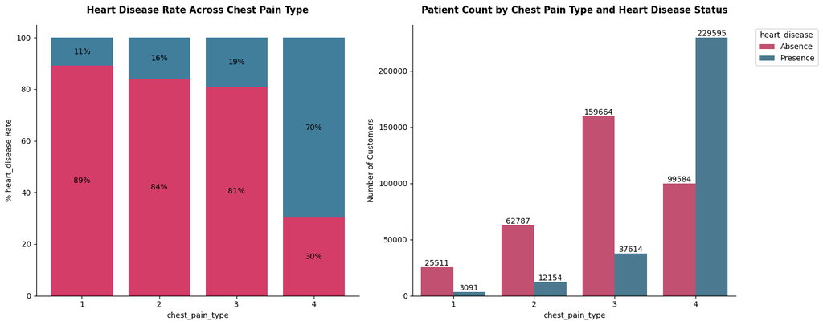

```
2026-02-02 19:42:25 | INFO | Chi-Square Test of Independence: 'chest_pain_type' vs. 'heart_disease'...
2026-02-02 19:42:25 | INFO | Chi-squared statistic: 173770.662
2026-02-02 19:42:25 | INFO | Degrees of freedom: 3
2026-02-02 19:42:25 | INFO | p-value: 0.000000
2026-02-02 19:42:25 | INFO | Result: p-value < 0.05 → Reject H₀
2026-02-02 19:42:25 | INFO | Variables 'chest_pain_type' and 'heart_disease' are statistically associated.
2026-02-02 19:42:25 | DEBUG | Displaying standardized residuals heatmap.
```

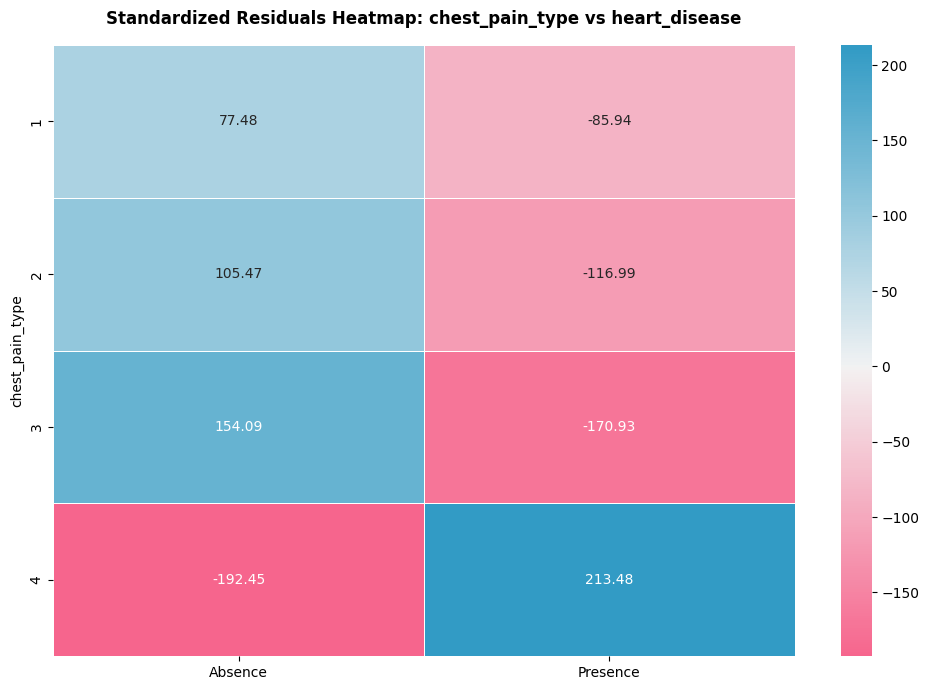

**Distribution of fbs_over_120 by heart_disease**

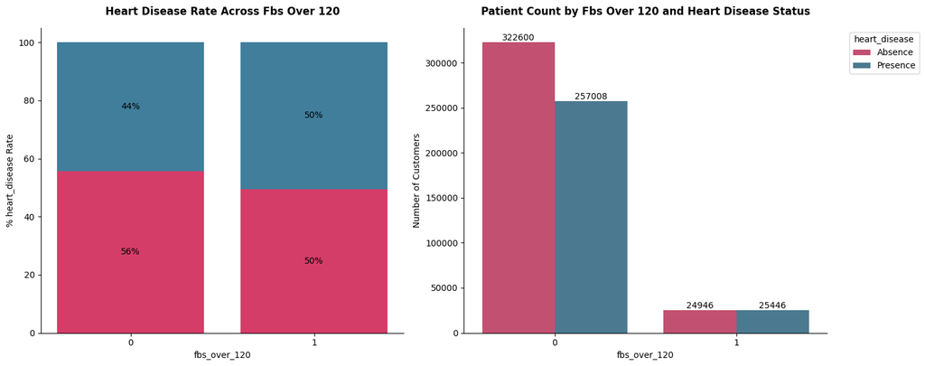

```
2026-02-02 19:42:26 | INFO | Chi-Square Test of Independence: 'fbs_over_120' vs. 'heart_disease'...
2026-02-02 19:42:26 | INFO | Chi-squared statistic: 709.738
2026-02-02 19:42:26 | INFO | Degrees of freedom: 1
2026-02-02 19:42:26 | INFO | p-value: 0.000000
2026-02-02 19:42:26 | INFO | Result: p-value < 0.05 → Reject H₀
2026-02-02 19:42:26 | INFO | Variables 'fbs_over_120' and 'heart_disease' are statistically associated.
2026-02-02 19:42:26 | DEBUG | Displaying standardized residuals heatmap.
```

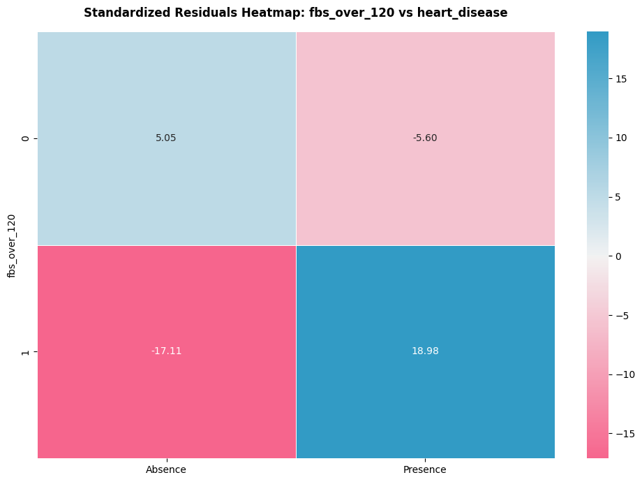

**Distribution of ekg_results by heart_disease**

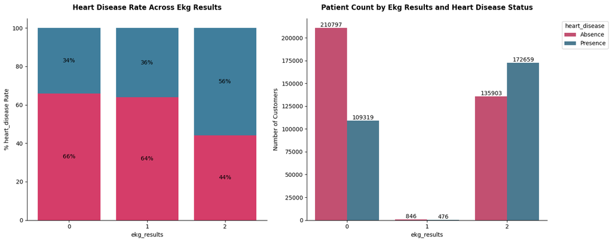

```
2026-02-02 19:42:27 | INFO | Chi-Square Test of Independence: 'ekg_results' vs. 'heart_disease'...
2026-02-02 19:42:28 | INFO | Chi-squared statistic: 30248.416
2026-02-02 19:42:28 | INFO | Degrees of freedom: 2
2026-02-02 19:42:28 | INFO | p-value: 0.000000
2026-02-02 19:42:28 | INFO | Result: p-value < 0.05 → Reject H₀
2026-02-02 19:42:28 | INFO | Variables 'ekg_results' and 'heart_disease' are statistically associated.
2026-02-02 19:42:28 | DEBUG | Displaying standardized residuals heatmap.
```

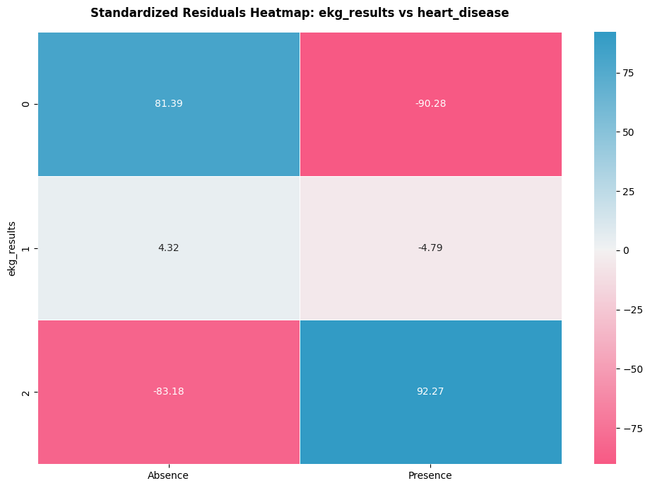

**Distribution of exercise_angina by heart_disease**

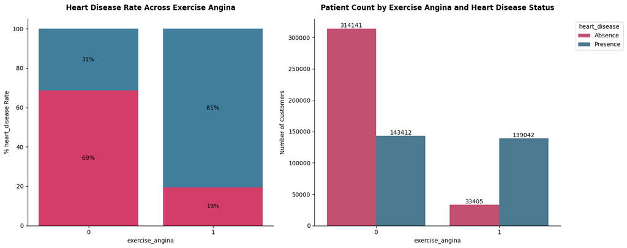

```
2026-02-02 19:42:29 | INFO | Chi-Square Test of Independence: 'exercise_angina' vs. 'heart_disease'...
2026-02-02 19:42:29 | INFO | Chi-squared statistic: 123001.448
2026-02-02 19:42:29 | INFO | Degrees of freedom: 1
2026-02-02 19:42:29 | INFO | p-value: 0.000000
2026-02-02 19:42:29 | INFO | Result: p-value < 0.05 → Reject H₀
2026-02-02 19:42:29 | INFO | Variables 'exercise_angina' and 'heart_disease' are statistically associated.
2026-02-02 19:42:29 | DEBUG | Displaying standardized residuals heatmap.
```

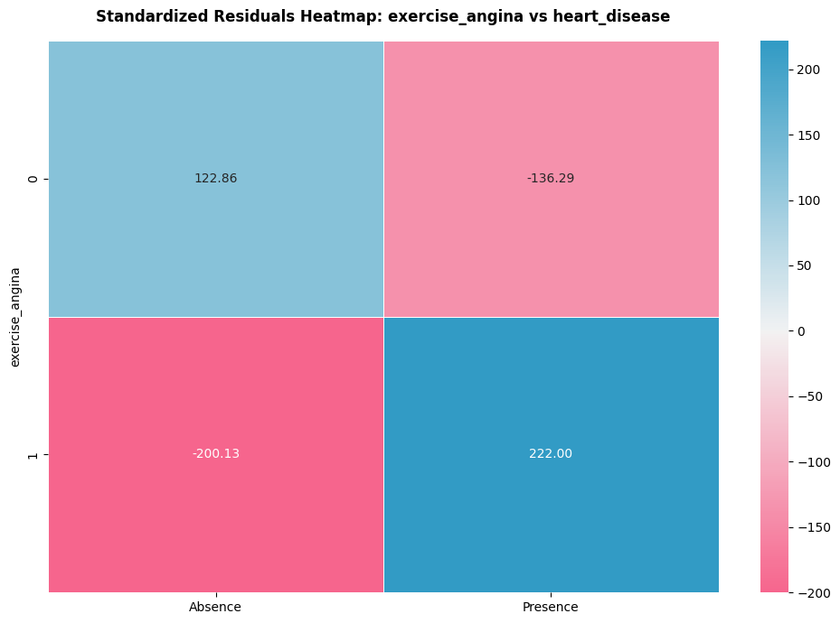

**Distribution of slope_of_st by heart_disease**

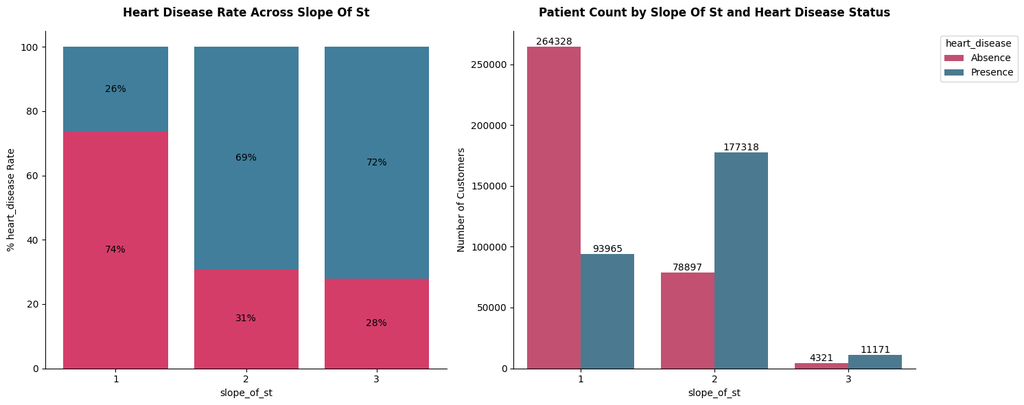

```
2026-02-02 19:42:30 | INFO | Chi-Square Test of Independence: 'slope_of_st' vs. 'heart_disease'...
2026-02-02 19:42:30 | INFO | Chi-squared statistic: 116357.579
2026-02-02 19:42:30 | INFO | Degrees of freedom: 2
2026-02-02 19:42:30 | INFO | p-value: 0.000000
2026-02-02 19:42:30 | INFO | Result: p-value < 0.05 → Reject H₀
2026-02-02 19:42:30 | INFO | Variables 'slope_of_st' and 'heart_disease' are statistically associated.
2026-02-02 19:42:30 | DEBUG | Displaying standardized residuals heatmap.
```

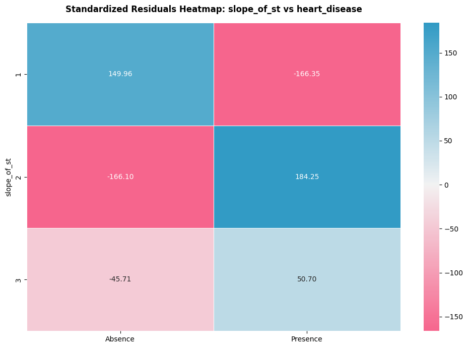

**Distribution of number_of_vessels_fluro by heart_disease**

[4 more figures not shown]

```python
def bivariate_percent_plot(cat: str, target_feature: str,
                           df: pd.DataFrame, figsize=(15, 6), order=None) -> None:
    """
    Plot the relationship between a categorical feature and the target variable.

    This function displays:
    - A stacked bar chart showing percentage distribution of target classes.
    - A count plot showing absolute frequencies.
    - A Chi-Square test for feature–target dependence.

    Parameters
    ----------
    cat : str
        Categorical feature name.

    target_feature : str
        Target variable name.

    df : pd.DataFrame
        Input dataset.

    figsize : tuple, optional
        Figure size (width, height). Default is (15, 6).

    order : list, optional
        Custom order of categories on x-axis.

    Returns
    -------
    None
    """

    display(HTML(f"<h2 style='text-align:center; font-size:22px; color:blue;'><b>Distribution of {cat} by {target_feature}</b></h2>"))
    fig, ax = plt.subplots(nrows=1, ncols=2, sharey=False, figsize=figsize)

    # Data processing
    grouped = df.groupby([cat, target_feature]).size().unstack(fill_value=0)

    # Define a fixed hue order (adjust if needed)
    target_order = [c for c in ["Absence", "Presence"] if c in grouped.columns]

    # Fallback if the labels are 0/1 or have different names
    if not target_order:
        target_order = list(grouped.columns)

    # Calculate percentages row-wise and reorder columns by target_order
    percentages = grouped.div(grouped.sum(axis=1), axis=0)[target_order] * 100

    # Define X-axis category order
    if order is not None:
        percentages = percentages.loc[order]
        labels = order
    else:
        labels = percentages.index.tolist()

    # Consistent color palette for both charts
    base_colors = color(n_colors=len(target_order))
    color_map = dict(zip(target_order, base_colors))

    # Plot 1: Stacked bar chart (percentage)
    bottom = np.zeros(len(percentages))
    for cls in target_order:
        ax[0].bar(percentages.index.astype(str), percentages[cls].values, bottom=bottom,
                  label=cls, color=color_map[cls])
        bottom += percentages[cls].values

    # Add percentage labels
    for container in ax[0].containers:
        ax[0].bar_label(container, fmt="%1.0f%%", label_type="center",
                        fontsize=10, color="black")

    ax[0].set_title(f"Heart Disease Rate Across {cat.replace('_', ' ').title()}", fontsize=12, weight="bold", pad=15)
    ax[0].set_xlabel(f"{cat}", fontsize=10)
    ax[0].set_ylabel(f"% {target_feature} Rate", fontsize=10)
    sns.despine(left=False, bottom=False, ax=ax[0])
    ax[0].legend().remove()

    # Plot 2: Count plot (using same color_map + hue_order)
    sns.countplot(data=df, hue=target_feature, x=cat,
                  order=labels, hue_order=target_order,
                  palette=color_map, ax=ax[1])

    for container in ax[1].containers:
        ax[1].bar_label(container, fmt="%d", label_type="edge",
                        fontsize=10, color="black")

    ax[1].set_title(f"Patient Count by {cat.replace('_', ' ').title()} and Heart Disease Status", fontsize=12, weight="bold", pad=15)
    ax[1].set_xlabel(f"{cat}", fontsize=10)
    ax[1].set_ylabel("Number of Customers", fontsize=10)
    ax[1].legend(title=target_feature, bbox_to_anchor=(1.05, 1), loc="upper left")
    sns.despine(left=False, bottom=False, ax=ax[1])
    plt.tight_layout()
    plt.show()

    # Chi-Square Test
    cal_ChiSquare(cat_feature=cat, target_feature=target_feature, df=df, show_residuals=True)

# Run for all categorical features
for feature in cat_features:
    bivariate_percent_plot(cat=feature, target_feature=config.target_feature,
                           df=df_train[cat_features_full].astype("category"))
```

- **Sex** Male patients face substantially higher heart disease risk and should be prioritized for early screening.
- **Chest Pain Type** Asymptomatic patients (Type 4) show the highest disease rate (~70%), making this one of the strongest predictors.
- **Fasting Blood Sugar (>120 mg/dL)** Elevated fasting blood sugar is significantly associated with heart disease, reflecting diabetes-related risk.
- **EKG Results** Abnormal ECG readings (Type 2) have the highest prevalence (~56%), indicating important cardiac abnormalities.
- **Exercise-Induced Angina** Patients experiencing chest pain during exercise show extremely high disease risk (~81%), making this a powerful clinical indicator.
- **Slope of ST Segment** Flat and down-sloping patterns (Types 2 and 3) are linked to much higher disease rates (~69%–72%).
- **Number of Vessels (Fluoroscopy)** Patients with 2–3 affected vessels have very high disease prevalence (~90%), representing one of the strongest diagnostic signals.
- **Thallium Test** Abnormal perfusion patterns (Type 7) show the highest risk (~82%), making this a key diagnostic feature.

## 📊 Overall Picture

| **Feature** | **Summary** |
| --- | --- |
| **sex** | Male patients show **substantially higher disease prevalence**, making gender an important demographic risk factor. |
| **chest_pain_type** | **One of the strongest predictors** — asymptomatic type (Type 4) has the highest risk (~70%), strongly indicating underlying heart disease. |
| **fbs_over_120** | Elevated fasting blood sugar is **significantly associated** with heart disease, reflecting diabetes-related cardiovascular risk. |
| **ekg_results** | Abnormal ECG patterns (Type 2) show **markedly higher prevalence (~56%)**, confirming ECG as a key diagnostic indicator. |
| **exercise_angina** | **Very strong predictor** — exercise-induced chest pain is linked to extremely high disease risk (~81%). |
| **slope_of_st** | Flat and down-sloping ST segments (Types 2–3) show **substantially elevated risk (~69%–72%)**, indicating ischemic abnormalities. |
| **number_of_vessels_fluro** | **One of the strongest imaging-based predictors** — patients with 2–3 affected vessels show very high prevalence (~90%). |
| **thallium** | **Highly powerful diagnostic feature** — abnormal perfusion (Type 7) shows the highest risk (~82%). |
| **age** | Heart disease patients are generally **older**, confirming age as a major non-modifiable risk factor. |
| **bp** | No meaningful difference between groups → blood pressure alone has **limited standalone predictive value**. |
| **cholesterol** | Statistically significant but **small practical effect**, serving mainly as a supporting risk marker. |
| **max_hr** | Diseased patients have **significantly lower exercise heart rates**, reflecting reduced cardiac capacity and strong predictive power. |
| **st_depression** | **Strong clinical indicator** — higher ST depression reflects myocardial ischemia and is strongly linked to heart disease. |

# Data Preprocessing

# Data Preprocessing

```python
BASE = [c for c in df_train.columns if c not in [config.id_column, config.target_feature]]
df_train[config.target_feature] = df_train[config.target_feature].map({"Absence": 0, "Presence": 1})
df_original[config.target_feature] = df_original[config.target_feature].map({"Absence": 0, "Presence": 1})
logger.info(f"[1/4] Data loaded | Train: {df_train.shape} | Test: {df_test.shape} | Original: {df_original.shape}")
```

```
2026-02-02 19:42:33 | INFO | [1/4] Data loaded | Train: (630000, 14) | Test: (270000, 13) | Original: (270, 14)
```

```python
ORIG = []
global_mean = df_original[config.target_feature].mean()

for col in BASE:
    if not col in df_original.columns:
        continue
    mean_map = df_original.groupby(col)[config.target_feature].mean()
    count_map = df_original[col].value_counts().to_dict()

    df_train[f"orig_mean_{col}"] = df_train[col].map(mean_map).fillna(global_mean)
    df_test[f"orig_mean_{col}"] = df_test[col].map(mean_map).fillna(global_mean)
    df_train[f"orig_count_{col}"] = df_train[col].map(count_map).fillna(0)
    df_test[f"orig_count_{col}"] = df_test[col].map(count_map).fillna(0)

    ORIG.extend([f"orig_mean_{col}", f"orig_count_{col}"])

for df in [df_train, df_test]:
    df["age_cholesterol"] = df["age"] * df["cholesterol"]
    df["bp_age"] = df["bp"] * df["age"]
    df["vessels_thallium"] = df["number_of_vessels_fluro"] * df["thallium"]
    df["chest_pain_vessels"] = df["chest_pain_type"] * df["number_of_vessels_fluro"]
    df["hr_age_ratio"] = df["max_hr"] / (df["age"] + 1)
    df["cholesterol_age_ratio"] = df["cholesterol"] / (df["age"] + 1)
    df["bp_ratio"] = df["bp"] / (df["age"] + 1)
    df["heart_risk_score"] = df["thallium"] * 3 + df["chest_pain_type"] * 2 + df["number_of_vessels_fluro"] * 2
    df["thallium_sq"] = df["thallium"] ** 2
    df["chest_pain_sq"] = df["chest_pain_type"] ** 2
    df["age_bin"] = pd.cut(df["age"], bins=[0, 40, 50, 60, 100], labels=False).fillna(0).astype(int)
    df["cholesterol_bin"] = pd.cut(df["cholesterol"], bins=[0, 40, 50, 60, 100], labels=False).fillna(0).astype(int)

new_features = ["age_cholesterol", "bp_age", "vessels_thallium", "chest_pain_vessels",
                "thallium_sq", "chest_pain_sq", "bp_ratio", "cholesterol_age_ratio",
                "hr_age_ratio", "age_bin", "cholesterol_bin", "heart_risk_score"]

ORIG.extend(new_features)
FEATURES = BASE + ORIG
logger.info(f"Total Features: {len(FEATURES)}")

X = df_train[FEATURES]
y = df_train[config.target_feature]
logger.info(f"X Shape: {X.shape}")
logger.info(f"y Shape: {y.shape}")
```

```
2026-02-02 19:42:34 | INFO | Total Features: 51
2026-02-02 19:42:34 | INFO | X Shape: (630000, 51)
2026-02-02 19:42:34 | INFO | y Shape: (630000,)
```

```python
class TargetEncoder(BaseEstimator, TransformerMixin):
    """
    Target Encoding transformer with optional K-Fold smoothing.

    This encoder replaces categorical values with aggregated statistics
    (e.g., mean target value) computed from the training data. It supports
    cross-validation encoding to prevent target leakage.

    Features:
    - Supports multiple aggregation functions (mean, median, etc.)
    - K-Fold out-of-fold encoding
    - Automatic or manual smoothing
    - Optional removal of original categorical columns
    - Compatible with scikit-learn pipelines
    """

    def __init__(self, cols_to_encode, aggs=["mean"], cv=config.n_split_kfold, smooth="auto",
                 drop_original=False, logger=logger):
        """
        Initialize TargetEncoder.

        Parameters
        ----------
        cols_to_encode : list
            List of categorical columns to encode.

        aggs : list, default=["mean"]
            Aggregation functions applied to target variable.

        cv : int, default=config.n_split_kfold
            Number of folds for out-of-fold encoding.

        smooth : str or float, default="auto"
            Smoothing factor ("auto" or numeric value).

        drop_original : bool, default=False
            Whether to drop original categorical columns.

        logger : logging.Logger
            Logger instance for monitoring encoder behavior.
        """

        self.cols_to_encode = cols_to_encode
        self.aggs = aggs
        self.cv = cv
        self.smooth = smooth
        self.drop_original = drop_original
        self.logger = logger

        # Store mappings and global statistics
        self.mappings_ = {}
        self.global_stats_ = {}

    # Fit encoder using full training data
    def fit(self, X, y):
        """
        Learn target statistics from full dataset.

        Parameters
        ----------
        X : pandas.DataFrame
            Feature matrix.

        y : pandas.Series
            Target variable.

        Returns
        -------
        self
        """

        # self.logger.info("Fitting TargetEncoder...")

        temp_df = X.copy()
        temp_df["target"] = y

        # Compute global target statistics
        for agg_func in self.aggs:
            self.global_stats_[agg_func] = y.agg(agg_func)

        # Compute category-level mappings
        for col in self.cols_to_encode:
            self.mappings_[col] = {}
            for agg_func in self.aggs:
                mapping = temp_df.groupby(col)["target"].agg(agg_func)
                self.mappings_[col][agg_func] = mapping

        # self.logger.info("TargetEncoder fitted successfully.")
        return self

    # Transform new data using learned mappings
    def transform(self, X):
        """
        Apply learned target encoding to new data.

        Parameters
        ----------
        X : pandas.DataFrame
            Input features.

        Returns
        -------
        pandas.DataFrame
            Transformed dataset with encoded features.
        """

        # self.logger.debug("Applying TargetEncoder transform...")
        X_transformed = X.copy()

        # Encode each categorical feature
        for col in self.cols_to_encode:
            for agg_func in self.aggs:
                new_col_name = f"TE_{col}_{agg_func}"
                map_series = self.mappings_[col][agg_func]

                # Map categories to statistics
                X_transformed[new_col_name] = X[col].map(map_series)

                # Fill unseen categories with global statistic
                X_transformed[new_col_name].fillna(self.global_stats_[agg_func], inplace=True)

        # Optionally drop original categorical columns
        if self.drop_original:
            X_transformed.drop(columns=self.cols_to_encode, inplace=True)

        return X_transformed

    # Fit-transform with K-Fold leakage prevention
    def fit_transform(self, X, y):
        """
        Perform out-of-fold target encoding using Stratified K-Fold.
        This method prevents target leakage by computing encodings
        only on training folds and applying them to validation folds.
        """

        # self.logger.info("Performing K-Fold target encoding...")

        # Fit global mappings
        self.fit(X, y)
        encoded_features = pd.DataFrame(index=X.index)

        # Stratified K-Fold for classification tasks
        kf = StratifiedKFold(n_splits=self.cv, shuffle=True, random_state=config.random_state)

        # Generate out-of-fold encodings
        for fold, (train_idx, val_idx) in enumerate(kf.split(X, y), start=1):

            # self.logger.debug(f"Processing fold {fold}/{self.cv}")
            X_train, y_train = X.iloc[train_idx], y.iloc[train_idx]
            X_val = X.iloc[val_idx]

            temp_df_train = X_train.copy()
            temp_df_train["target"] = y_train

            for col in self.cols_to_encode:
                for agg_func in self.aggs:
                    new_col_name = f"TE_{col}_{agg_func}"
                    fold_global_stat = y_train.agg(agg_func)
                    mapping = temp_df_train.groupby(col)["target"].agg(agg_func)

                    # Apply smoothing for mean encoding
                    if agg_func == "mean":
                        counts = temp_df_train.groupby(col)["target"].count()

                        # Auto smoothing factor
                        m = self.smooth
                        if self.smooth == "auto":
                            variance_between = mapping.var()
                            avg_variance_within = temp_df_train.groupby(col)["target"].var().mean()
                            if variance_between > 0:
                                m = avg_variance_within / variance_between
                            else:
                                m = 0

                        # Smoothed mean encoding
                        smoothed_mapping = (counts * mapping + m * fold_global_stat) / (counts + m)
                        encoded_values = X_val[col].map(smoothed_mapping)
                    else:
                        encoded_values = X_val[col].map(mapping)

                    # Handle unseen categories
                    encoded_features.loc[X_val.index, new_col_name] = encoded_values.fillna(fold_global_stat)

        # Merge encoded features into final dataset
        X_transformed = X.copy()
        for col in encoded_features.columns:
            X_transformed[col] = encoded_features[col]

        # Optionally remove original categorical columns
        if self.drop_original:
            X_transformed.drop(columns=self.cols_to_encode, inplace=True)

        # self.logger.info("Target encoding completed.")

        return X_transformed
```

# Modeling

# Modeling

```python
datasets = [
    ("Train Set", X),
    ("Test Set", df_test)
]

for name, df in datasets:
    logger.info(f"Processing {name}")
    logger.info(f"{name} memory before: {config.memory_report(df):.2f} MB")

    config.reduce_mem_usage(FEATURES, df)

    logger.info(f"{name} memory after: {config.memory_report(df):.2f} MB")
    logger.info("*" * 80)
```

```
2026-02-02 19:42:34 | INFO | Processing Train Set
2026-02-02 19:42:34 | INFO | Train Set memory before: 245.13 MB
2026-02-02 19:42:34 | INFO | Train Set memory after: 81.71 MB
2026-02-02 19:42:34 | INFO | ********************************************************************************
2026-02-02 19:42:34 | INFO | Processing Test Set
2026-02-02 19:42:34 | INFO | Test Set memory before: 105.06 MB
2026-02-02 19:42:34 | INFO | Test Set memory after: 35.02 MB
2026-02-02 19:42:34 | INFO | ********************************************************************************
```

```python
def plot_oof_metrics(y_true, oof_preds, fold_preds, threshold=0.5):
    """
    Plot ROC, Precision-Recall curves (by fold) and Confusion Matrix (OOF)

    Parameters
    ----------
    y_true : array-like
        Ground truth labels

    oof_preds : array-like
        Out-of-fold predicted probabilities

    fold_preds : list of tuples
        Each element: (y_val, val_pred) for each fold

    threshold : float, default=0.5
        Threshold for confusion matrix
    """

    roc_curves = []
    pr_curves = []
    auc_values = []
    ap_values = []

    # ================= Collect metrics per fold =================
    for i, (y_val, val_pred) in enumerate(fold_preds):
        # ROC
        fpr, tpr, _ = roc_curve(y_val, val_pred)
        roc_curves.append((fpr, tpr))

        auc = roc_auc_score(y_val, val_pred)
        auc_values.append(auc)

        # PR
        precision, recall, _ = precision_recall_curve(y_val, val_pred)
        pr_curves.append((recall, precision))

        ap = average_precision_score(y_val, val_pred)
        ap_values.append(ap)

    # ================= Plot =================
    fig, axes = plt.subplots(2, 2, figsize=(16, 14))

    # ---------------- ROC ----------------
    ax = axes[0, 0]

    for i, (fpr, tpr) in enumerate(roc_curves):
        ax.plot(fpr, tpr, label=f"Fold {i+1} AUC = {auc_values[i]:.4f}")

    ax.plot([0, 1], [0, 1], "--", color="gray")
    ax.set_title("ROC Curve (Each Fold)", weight="bold")
    ax.set_xlabel("False Positive Rate")
    ax.set_ylabel("True Positive Rate")
    ax.legend()
    ax.grid(True)

    # ---------------- PR ----------------
    ax = axes[0, 1]

    for i, (recall, precision) in enumerate(pr_curves):
        ax.plot(recall, precision, label=f"Fold {i+1} AP = {ap_values[i]:.4f}")

    ax.set_title("Precision–Recall Curve (Each Fold)", weight="bold", pad=15, fontsize=12)
    ax.set_xlabel("Recall")
    ax.set_ylabel("Precision")
    ax.legend()
    ax.grid(True)

    # ---------------- Confusion Matrix ----------------
    ax = axes[1, 0]

    y_pred_label = (oof_preds >= threshold).astype(int)
    cm = confusion_matrix(y_true, y_pred_label)

    sns.heatmap(cm, annot=True, fmt="d", cmap="Blues", ax=ax)
    ax.set_title(f"Confusion Matrix (Threshold = {threshold})", weight="bold", pad=15, fontsize=12)
    ax.set_xlabel("Predicted")
    ax.set_ylabel("True")

    # Empty plot
    axes[1, 1].axis("off")

    plt.tight_layout()
    plt.show()
```

## XGBClassifier

```
2026-02-02 19:42:35 | INFO | Target Encoding: 10 features
2026-02-02 19:42:35 | INFO | ================================================================================
2026-02-02 19:42:35 | INFO | XGBOOST TRAINING START
2026-02-02 19:42:35 | INFO | ================================================================================
2026-02-02 19:43:14 | DEBUG | Fold 1...
2026-02-02 19:43:14 | DEBUG | Fold 1 - AUC: 0.95518
2026-02-02 19:43:54 | DEBUG | Fold 2...
2026-02-02 19:43:54 | DEBUG | Fold 2 - AUC: 0.95406
2026-02-02 19:44:33 | DEBUG | Fold 3...
2026-02-02 19:44:33 | DEBUG | Fold 3 - AUC: 0.95506
2026-02-02 19:45:13 | DEBUG | Fold 4...
2026-02-02 19:45:13 | DEBUG | Fold 4 - AUC: 0.95454
2026-02-02 19:45:52 | DEBUG | Fold 5...
2026-02-02 19:45:52 | DEBUG | Fold 5 - AUC: 0.95536
2026-02-02 19:45:52 | INFO | ================================================================================
2026-02-02 19:45:52 | INFO | XGB OOF AUC: 0.95483
2026-02-02 19:45:52 | INFO | ================================================================================
```

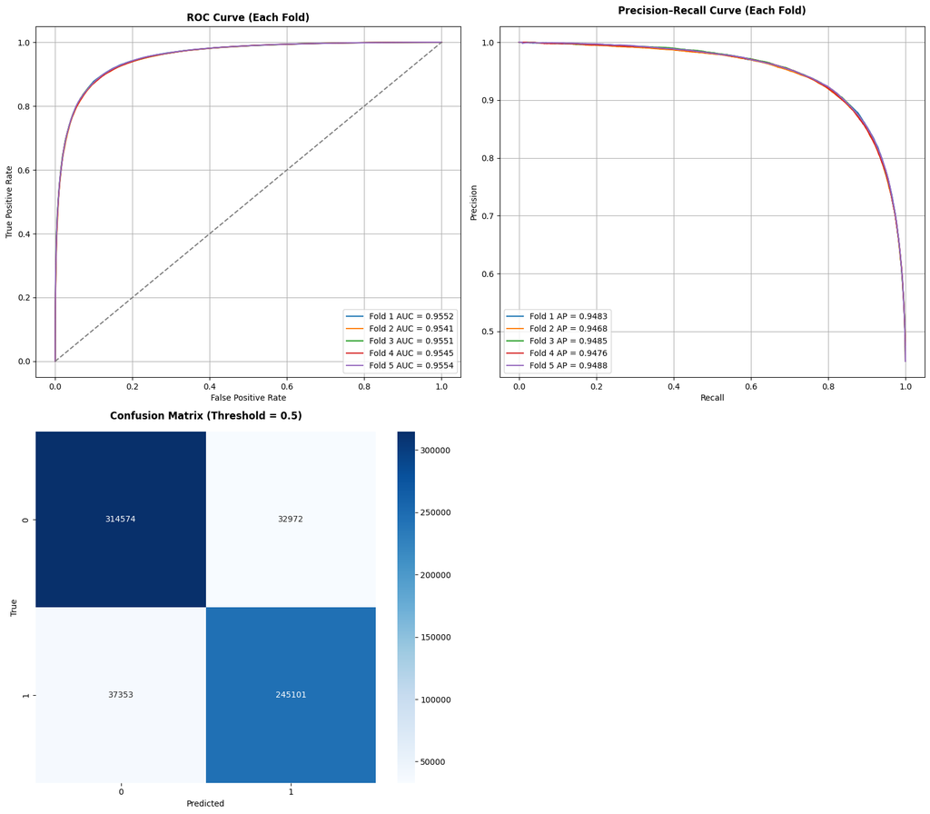

```python
NUMS_ORIGINAL = ["age", "sex", "chest_pain_type", "bp", "cholesterol", "fbs_over_120", "ekg_results", "max_hr",
                 "exercise_angina", "st_depression", "slope_of_st", "number_of_vessels_fluro", "thallium"]

# Out-of-Fold predictions for training set (used for global validation)
xgb_oof_preds = np.zeros(len(X))
# Averaged predictions for test set (from all folds)
xgb_test_preds = np.zeros(len(df_test))

# Store predictions of each fold for later visualization/analysis
# Each element: (true_labels, predicted_probs)
fold_preds = []

# Stratified K-Fold to preserve label distribution
kf = StratifiedKFold(n_splits=config.n_split_kfold, shuffle=True, random_state=config.random_state)

# Select features for Target Encoding
# Only apply to columns with more than 2 unique values
TE_COLS = [col for col in NUMS_ORIGINAL if df_train[col].nunique() > 2]

logger.info(f"Target Encoding: {len(TE_COLS)} features")
logger.info("="*80)
logger.info("XGBOOST TRAINING START")
logger.info("="*80)

# Cross-validation training loop
for fold, (train_idx, val_idx) in enumerate(kf.split(X, y), 1):

    # Split training and validation data
    X_train, y_train = X.iloc[train_idx].copy(), y.iloc[train_idx]
    X_val, y_val = X.iloc[val_idx].copy(), y.iloc[val_idx]

    # Prepare test set for this fold
    X_test_fold = df_test[FEATURES].copy()

    # Apply Target Encoding (if applicable)
    if len(TE_COLS) > 0:
        TE = TargetEncoder(cols_to_encode=TE_COLS, cv=config.n_split_kfold, smooth="auto",
                           aggs=["mean", "count"], drop_original=False)

        # Fit only on training data (avoid leakage)
        X_train = TE.fit_transform(X_train, y_train)

        # Transform validation and test
        X_val = TE.transform(X_val)
        X_test_fold = TE.transform(X_test_fold)

    # Train XGBoost model
    model_xgb = XGBClassifier(**config.xgb_params)
    model_xgb.fit(X_train, y_train, eval_set=[(X_val, y_val)], verbose=False)

    # Predict probability for positive class
    val_preds = model_xgb.predict_proba(X_val)[:, 1]

    # Store OOF predictions
    xgb_oof_preds[val_idx] = val_preds

    # Store fold predictions for plotting
    fold_preds.append((y_val.values, val_preds))

    # Average predictions across folds
    xgb_test_preds += model_xgb.predict_proba(X_test_fold)[:, 1] / kf.get_n_splits()

    # Evaluate fold performance
    fold_score = roc_auc_score(y_val, val_preds)

    logger.debug(f"Fold {fold}...")
    logger.debug(f"Fold {fold} - AUC: {fold_score:.5f}")

    # Cleanup to save memory
    if len(TE_COLS) > 0:
        del TE
    gc.collect()

# Final OOF evaluation
logger.info("="*80)
logger.info(f"XGB OOF AUC: {roc_auc_score(y, xgb_oof_preds):.5f}")
logger.info("="*80)

# Plot OOF + Fold Metrics
plot_oof_metrics(y_true=y.values, oof_preds=xgb_oof_preds, fold_preds=fold_preds, threshold=0.5)
```

## LGBMClassifier

```
2026-02-02 19:45:55 | INFO | ================================================================================
2026-02-02 19:45:55 | INFO | LIGHTGBM TRAINING START
2026-02-02 19:45:55 | INFO | ================================================================================
2026-02-02 19:46:48 | DEBUG | Fold 1...
2026-02-02 19:46:48 | DEBUG | Fold 1 - AUC: 0.95567
2026-02-02 19:47:40 | DEBUG | Fold 2...
2026-02-02 19:47:40 | DEBUG | Fold 2 - AUC: 0.95455
2026-02-02 19:48:36 | DEBUG | Fold 3...
2026-02-02 19:48:36 | DEBUG | Fold 3 - AUC: 0.95544
2026-02-02 19:49:35 | DEBUG | Fold 4...
2026-02-02 19:49:35 | DEBUG | Fold 4 - AUC: 0.95501
2026-02-02 19:50:30 | DEBUG | Fold 5...
2026-02-02 19:50:30 | DEBUG | Fold 5 - AUC: 0.95587
2026-02-02 19:50:30 | INFO | ================================================================================
2026-02-02 19:50:30 | INFO | LGBM OOF AUC: 0.95531
2026-02-02 19:50:30 | INFO | ================================================================================
```

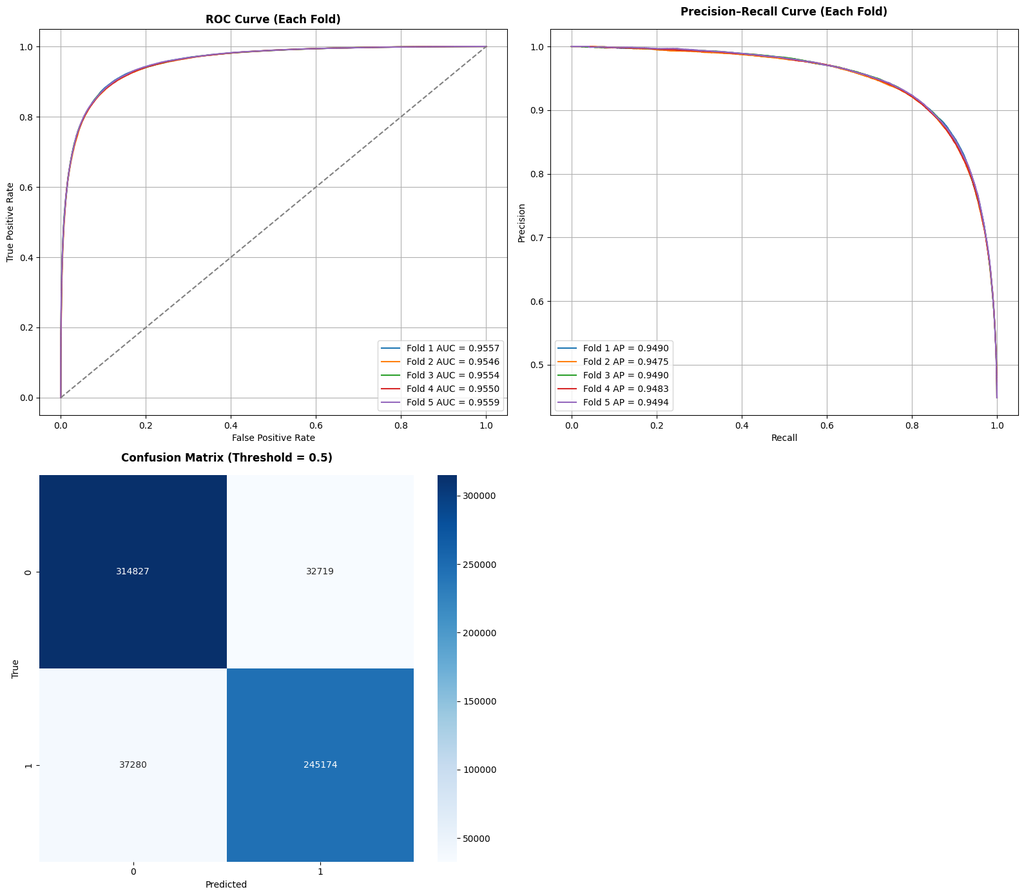

```python
# Store predictions of each fold for later visualization/analysis
# Each element: (true_labels, predicted_probs)
fold_preds = []

# Out-of-Fold predictions for training set (used for global validation)
lgb_oof_preds = np.zeros(len(X))
# Averaged predictions for test set (from all folds)
lgb_test_preds = np.zeros(len(df_test))

logger.info("="*80)
logger.info("LIGHTGBM TRAINING START")
logger.info("="*80)

for fold, (train_idx, val_idx) in enumerate(kf.split(X, y), 1):
    # Split training and validation data
    X_train, y_train = X.iloc[train_idx].copy(), y.iloc[train_idx]
    X_val, y_val = X.iloc[val_idx].copy(), y.iloc[val_idx]

    # Prepare test set for this fold
    X_test_fold = df_test[FEATURES].copy()

    # Apply Target Encoding (if applicable)
    if len(TE_COLS) > 0:
        TE = TargetEncoder(cols_to_encode=TE_COLS, cv=config.n_split_kfold, smooth="auto",
                           aggs=["mean", "count"], drop_original=False)

        # Fit only on training data (avoid leakage)
        X_train = TE.fit_transform(X_train, y_train)

        # Transform validation and test
        X_val = TE.transform(X_val)
        X_test_fold = TE.transform(X_test_fold)

    # Train LGBM model
    model_lgbm = lgb.LGBMClassifier(**config.lgb_params)

    model_lgbm.fit(
        X_train, y_train,
        eval_set=[(X_val, y_val)],
        eval_metric="auc",
        callbacks=[lgb.early_stopping(stopping_rounds=300, verbose=False)]
    )

    # Predict probability for positive class
    val_preds = model_lgbm.predict_proba(X_val)[:, 1]

    # Store OOF predictions
    lgb_oof_preds[val_idx] = val_preds

    # Store fold predictions for plotting
    fold_preds.append((y_val.values, val_preds))

    # Average predictions across folds
    lgb_test_preds += model_lgbm.predict_proba(X_test_fold)[:, 1] / kf.get_n_splits()

    # Average predictions across folds
    fold_score = roc_auc_score(y_val, val_preds)

    logger.debug(f"Fold {fold}...")
    logger.debug(f"Fold {fold} - AUC: {fold_score:.5f}")

    if len(TE_COLS) > 0:
        del TE
    gc.collect()

logger.info("="*80)
logger.info(f"LGBM OOF AUC: {roc_auc_score(y, lgb_oof_preds):.5f}")
logger.info("="*80)

# Plot OOF + Fold Metrics
plot_oof_metrics(y_true=y.values, oof_preds=lgb_oof_preds, fold_preds=fold_preds, threshold=0.5)
```

## CatBoostClassifier

```
2026-02-02 19:50:32 | INFO | ================================================================================
2026-02-02 19:50:32 | INFO | CATBOOST TRAINING START
2026-02-02 19:50:32 | INFO | ================================================================================
2026-02-02 19:51:16 | DEBUG | Fold 1...
2026-02-02 19:51:16 | DEBUG | Fold 1 - AUC: 0.95580
2026-02-02 19:51:38 | DEBUG | Fold 2...
2026-02-02 19:51:38 | DEBUG | Fold 2 - AUC: 0.95470
2026-02-02 19:52:01 | DEBUG | Fold 3...
2026-02-02 19:52:01 | DEBUG | Fold 3 - AUC: 0.95552
2026-02-02 19:52:27 | DEBUG | Fold 4...
2026-02-02 19:52:27 | DEBUG | Fold 4 - AUC: 0.95511
2026-02-02 19:52:51 | DEBUG | Fold 5...
2026-02-02 19:52:51 | DEBUG | Fold 5 - AUC: 0.95596
2026-02-02 19:52:51 | INFO | ================================================================================
2026-02-02 19:52:51 | INFO | CATBOOST OOF AUC: 0.95541
2026-02-02 19:52:51 | INFO | ================================================================================
```

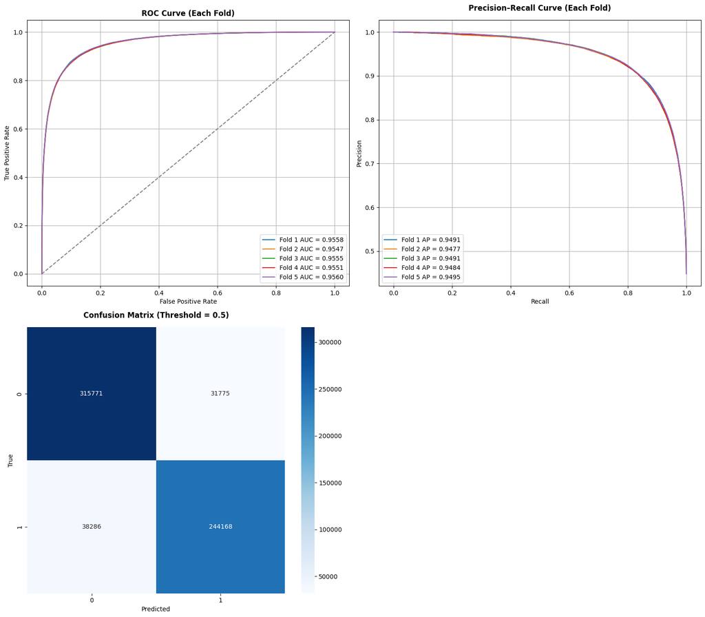

```python
# Store predictions of each fold for later visualization/analysis
# Each element: (true_labels, predicted_probs)
fold_preds = []

# Out-of-Fold predictions for training set (used for global validation)
catboost_oof_preds = np.zeros(len(X))
# Averaged predictions for test set (from all folds)
catboost_test_preds = np.zeros(len(df_test))

logger.info("="*80)
logger.info("CATBOOST TRAINING START")
logger.info("="*80)

for fold, (train_idx, val_idx) in enumerate(kf.split(X, y), 1):
    # Split training and validation data
    X_train, y_train = X.iloc[train_idx].copy(), y.iloc[train_idx]
    X_val, y_val = X.iloc[val_idx].copy(), y.iloc[val_idx]

    # Prepare test set for this fold
    X_test_fold = df_test[FEATURES].copy()

    # Apply Target Encoding (if applicable)
    if len(TE_COLS) > 0:
        TE = TargetEncoder(cols_to_encode=TE_COLS, cv=config.n_split_kfold, smooth="auto",
                           aggs=["mean", "count"], drop_original=False)

        # Fit only on training data (avoid leakage)
        X_train = TE.fit_transform(X_train, y_train)

        # Transform validation and test
        X_val = TE.transform(X_val)
        X_test_fold = TE.transform(X_test_fold)

    # Train Catboost model
    model_cat = CatBoostClassifier(**config.cat_params)
    model_cat.fit(
        X_train, y_train,
        eval_set=(X_val, y_val),
        early_stopping_rounds=300
    )

    # Predict probability for positive class
    val_preds = model_cat.predict_proba(X_val)[:, 1]

    # Store OOF predictions
    catboost_oof_preds[val_idx] = val_preds

    # Store fold predictions for plotting
    fold_preds.append((y_val.values, val_preds))

    # Average predictions across folds
    catboost_test_preds += model_cat.predict_proba(X_test_fold)[:, 1] / kf.get_n_splits()

    # Average predictions across folds
    fold_score = roc_auc_score(y_val, val_preds)

    logger.debug(f"Fold {fold}...")
    logger.debug(f"Fold {fold} - AUC: {fold_score:.5f}")

    if len(TE_COLS) > 0:
        del TE
    gc.collect()

logger.info("="*80)
logger.info(f"CATBOOST OOF AUC: {roc_auc_score(y, catboost_oof_preds):.5f}")
logger.info("="*80)

# Plot OOF + Fold Metrics
plot_oof_metrics(y_true=y.values, oof_preds=catboost_oof_preds, fold_preds=fold_preds, threshold=0.5)
```